# BARCODE project

Francesca Biondo

16/09/2022

This script presents the analyses used for the paper titled “Brain-age is associated with progression to dementia in memory clinic patients” (2022), Biondo, F., Jewell, A., Pritchard, M., Aarsland, A., Steves,C.J., Mueller,C., Cole, J.H. https://doi.org/10.1016/j.nicl.2022.103175

This research project is referred to as BARCODE - Brain Ageing and Risk of Cognitive Decline with the Maudsley Biomedical Research Centre Clinical Record Interactive Search (CRIS) reference number 19-008. This script uses the data extraction version 11/11/2019 of the BARCODE project.

The electronic health records (EHRs) were accessed via CRIS at the Maudsley BRC and used 3 databases: SLaM (in this script referered to as CRIS), HES (Hospital Episode Statistics) and mortality data via the ONS (Office of National Statistics). The EHRs data extraction was specified by the authors (F.B.& J.H.C) in May-August 2019 and executed by researchers at the Maudsley BRC (A.J. & M.P.).

The first data input to this script is the clinical information from the EHRS of 3666 memory clinic patients and includes the time-of-scan. The second data input is the neuroimaging data (brain-age values for each patient) which is merged with the clinical data just before FILTER4.

In this study we classify the memory clinic patients as of two types: the ones who go on to receive a dementia diagnosis (in this script labelled interchangeably as “DEM”, “Dementia” “futureDD” or “future Dementia Diagnosis”) and the ones who don’t go on to get a dementia diagnosis (labelled interchangeably as “DIAG”, “NonDementia”, “noDD” or “no dementia diagnosis”).

The script has 4 main parts: 1) Setting up: getting the libraries installed + a summary of the operational definition of how the data was extracted 2) Load data and data cleaning: sub-setting of data according to relevant constraints 3) Descriptives: summary statistics + plots 4) Statistical Analyses: Logistic Regression & Cox Proportional Hazards Regression

This script is dynamic such that changing the settings in the “Set settings” chunk will change the type of analysis carried out i.e. the main analyses, or one of the 3 sensitivity analyses.

CONTACT: For any comments and/or report of errors, please email me at f.biondo@ucl.ac.uk.

CITE: Please cite this paper if you use any of this work/code: Biondo, F., Jewell, A., Pritchard, M., Aarsland, A., Steves,C.J., Mueller,C., Cole, J.H.(2022) Brain-age is associated with progression to dementia in memory clinic patients. NeuroImage: Clinical, Vol36. https://doi.org/10.1016/j.nicl.2022.103175

# PART 1: setting-up

### Install packages

```r
#install Rtools
install.packages('tidyverse')
install.packages('caret')
install.packages('survival')
#uninstall Rtools (C:\Rtools)


install.packages("kableExtra")
install.packages('stats')
install.packages('survival')
install.packages('arm')
install.packages('Amelia')
install.packages('car')

install.packages('cowplot')
install.packages('data.table')
install.packages('dplyr')
install.packages('DescTools')
install.packages('ggplot2')
install.packages('Hmisc')
install.packages('memisc')
install.packages('openxlsx')
install.packages('pastecs')
install.packages('plyr')
install.packages('plotly')
install.packages('pander')
install.packages('reghelper')
install.packages('stringr')
install.packages('survminer')
install.packages('tidyr')
install.packages('readxl')
#install.packages("nlme")
install.packages("lme4")
install.packages("statmod")
install.packages('ggExtra')
```

### Call libraries

```r
#R version used is 3.6.1
library(ggplot2)
library(plyr)
library(data.table)
library(stats)
library(memisc)
library(openxlsx)
library(stringr)
library(dplyr)
library(tidyr)
library(tidyverse)
library(Amelia)
library(DescTools)
library(survival)
library(survminer)
library(cowplot)
library(pastecs)
library(Hmisc)
library(reghelper)
library(car)
library(caret)
library(plotly)
library(pander)
#library(nlme)
library(lme4)
library(statmod)
library(arm)
library(kableExtra)
library(readxl)
library(ggExtra)
```

### Set settings

```r
#clear workspace
rm(list = ls())
```

```r
#choose which version: 'main_analysis', sensitivity1, sensitivity2, sensitivity3
versionname <- "sensitivity2"

# subversion list based on True/False state of 3 parameters: Center, Scale, Poly; giving the following combos:
#1) PolyT, CentT = TFT: data is centered, age and age2 polynomials included
#2) PolyT, CentZ = TTT: data is standardized, age and age2 polynomials included
#3) PolyT, CentF = FFT: data is raw, age and age2 polynomials included
#4) PolyF, CentT = TFF: data is centered,age2 and poly excluded
#5) PolyF, CentZ = TTF: data is standardized, age2 and poly excluded
#6) PolyF, CentF = FFF: data is raw, age2 and poly excluded

# Table outputs are generated for all sub-versions above automatically, however please set subversion setting for detailed regression outputs below. As default I use TFT:
fCenter <- T
fScale <- F
fPoly <- T

#other settings
outputpath <- "U:\\aSLaM_2BARCODE_analysis\\Output\\"
inputpath <- "U:\\aSLaM_1BARCODE_data_PID_SLAMonly\\"
picres <- 280 #dpi setting for saving pics, I'm using 280 for high-res and 50 for low-res
options(knitr.table.format = 'markdown')
SET_dp <- 6 #set decimal places for rounding (originally 2dp, but 6dp necessary for norm vol)
```

### Data Extraction at the Maudsley BRC (via CRIS)

The EHRs data used was the one extracted on the 11/11/2019 with a 16/06/2020 update for a few variables. Part of this extraction involved defining the ‘end-time’ i.e. the way which a patient was defined as Dementia or Non-Dementia and setting a date for this event based on the source of the info (i.e. source is either SLaM (coded here as CRIS), HES or ONS databases). Here is a picture with a logical flowchart which was used to guide the extraction. DEM refers to the the Future Dementia Diagnosis patients and DIAG refers to the No Dementia Diagnosis patients. CRIS(SLAM)/HES/ONS refer to the databases used to establish the patient status: South London and Maudsley hospital data via CRIS, Hospital Episode Statistics and Office of National Statistics.

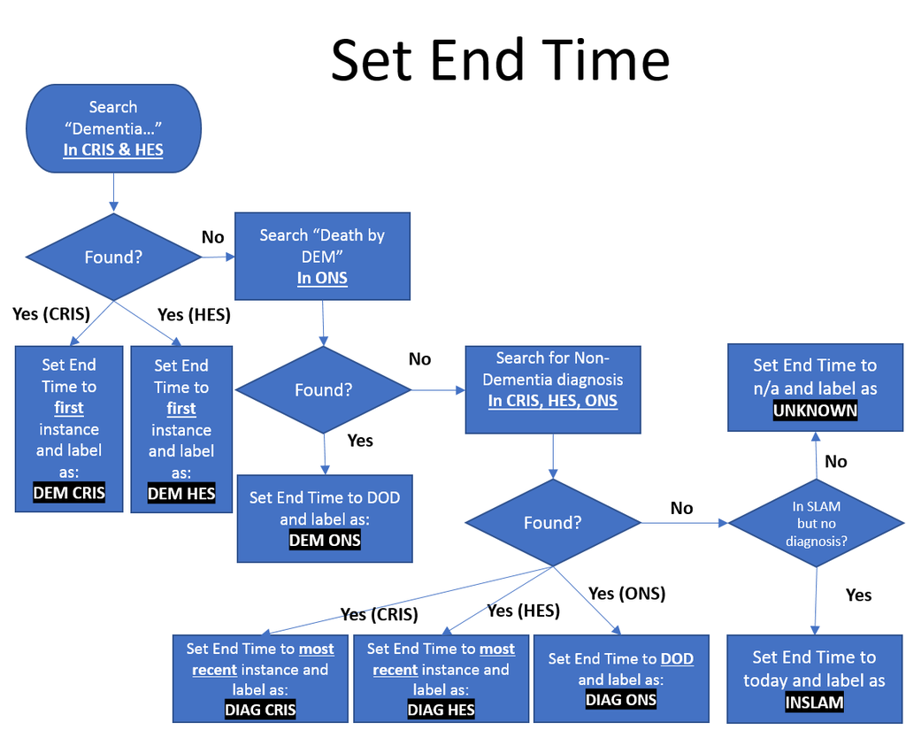

# PART 2: Load and clean data ### Read EHRs data

```r
#read data
data <- data.table(read_excel(paste(inputpath,'Data11102019.xlsx',sep="")))

#read data update
data_update <- data.table(read_excel(paste(inputpath,'HONOS65_Updated_ACE_16062020.xlsx',sep="")))

#merge dataframes
data <- merge(data,data_update,all.x=T,by.x="Brcid",by.y="Brcid")
```

### Date functions

```r
#Function to convert excel dates to proper dates
xldat2propdat <- function(x) {
  if (class(x)=="POSIXct") {
  date <- as.Date(x,origin="1899-12-30",optional=TRUE)
  } else if (class(x)=="character") {
    x <- as.numeric(x)
  date <- as.Date(x,origin="1899-12-30",optional=TRUE)
  } else if (class(x)=="factor") {
  x <- as.character(x)

  } else {
    print("class input not as expected")
  }

}

#Function to check if class of element is Date
classISdat <- function(x){
  if (class(x)!="Date") {
    print ("Fail! class is not Date")
  } else {
    print ("Success! class is Date")
  }
}
```

### Transform Dates

Dates are incorrectly set and need transformation.

```r
#select the columns for date conversion
cols=c("Start_Time","OUT_End_time","IN_CRIS_Diag_DEM_date","OUT_CRIS_Diag_DEM_prox_ante_date",
       "OUT_HES_Diag_DEM_prox_ante_date","OUT_ONS_DOD","OUT_CRIS_Diag_other_primary_dist_ante_date",
       "OUT_HES_Diag_other_primary_dist_ante_date","OUT_HES_dischargedHES_dist_ante_date")

#Before transformation: are these Dates?
data[,lapply(.SD,classISdat),.SDcols=cols]#.SD = subset of Data i.e. the cols
```

```
## [1] "Fail! class is not Date"
## [1] "Fail! class is not Date"
## [1] "Fail! class is not Date"
## [1] "Fail! class is not Date"
## [1] "Fail! class is not Date"
## [1] "Fail! class is not Date"
## [1] "Fail! class is not Date"
## [1] "Fail! class is not Date"
## [1] "Fail! class is not Date"
```

```
##                 Start_Time            OUT_End_time   IN_CRIS_Diag_DEM_date
## 1: Fail! class is not Date Fail! class is not Date Fail! class is not Date
##    OUT_CRIS_Diag_DEM_prox_ante_date OUT_HES_Diag_DEM_prox_ante_date
## 1:          Fail! class is not Date         Fail! class is not Date
##                OUT_ONS_DOD OUT_CRIS_Diag_other_primary_dist_ante_date
## 1: Fail! class is not Date                    Fail! class is not Date
##    OUT_HES_Diag_other_primary_dist_ante_date
## 1:                   Fail! class is not Date
##    OUT_HES_dischargedHES_dist_ante_date
## 1:              Fail! class is not Date
```

```r
#Transform and replace those columns with output
data[,(cols):=lapply(.SD,xldat2propdat),.SDcols=cols]# := allows replacement

#After transformation: are these Dates?
data[,lapply(.SD,classISdat),.SDcols=cols]
```

```
## [1] "Success! class is Date"
## [1] "Success! class is Date"
## [1] "Success! class is Date"
## [1] "Success! class is Date"
## [1] "Success! class is Date"
## [1] "Success! class is Date"
## [1] "Success! class is Date"
## [1] "Success! class is Date"
## [1] "Success! class is Date"
```

```
##                Start_Time           OUT_End_time  IN_CRIS_Diag_DEM_date
## 1: Success! class is Date Success! class is Date Success! class is Date
##    OUT_CRIS_Diag_DEM_prox_ante_date OUT_HES_Diag_DEM_prox_ante_date
## 1:           Success! class is Date          Success! class is Date
##               OUT_ONS_DOD OUT_CRIS_Diag_other_primary_dist_ante_date
## 1: Success! class is Date                     Success! class is Date
##    OUT_HES_Diag_other_primary_dist_ante_date
## 1:                    Success! class is Date
##    OUT_HES_dischargedHES_dist_ante_date
## 1:               Success! class is Date
```

### FILTER1: Dementia before scan

Out of those with a Dementia diagnosis, how many had such a diagnosis before their scan? (remove these cases) Similarly, out of those with a Non-Dementia diagnosis, how many had their last diagnosis before the scan? (remove these cases)

```r
#Who was diagnosed before the scan? i.e. whose end time is before the start time?
data <- data%>%
  mutate(FRAN_endb4start=OUT_End_time<Start_Time)
```

First, we’ll plot the whole sample by the neuroimaging source: BRCMEM (primarily SLaM memory clinics) and BRCDEM (other psychiatric referrals). Second, we’ll plot by patient type (Dementia or Non-Dementia) and the database source from where the patient type was defined from: CRIS, HES or ONS databases.

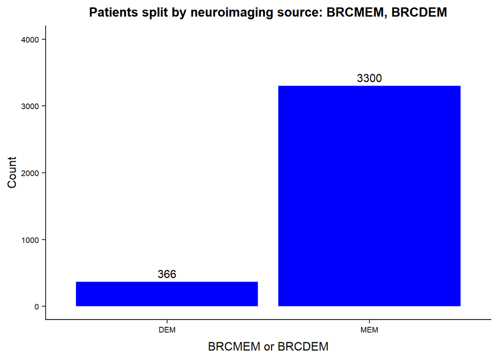

```r
summary_variable1 <- ddply(data,.(Mem_or_Dem), summarise, y=length(Mem_or_Dem)) %>%

  ggplot(aes(x=Mem_or_Dem,y=y,fill=Mem_or_Dem))+ #plot!
  geom_bar(stat="identity",fill="blue")+
  theme_cowplot()+
  geom_text(aes(label=y),vjust=-0.5,cex=4)+
  labs(x="BRCMEM or BRCDEM",y="Count")+
  ylim(0,4000)+
  theme(plot.title=element_text(hjust=0.5,size=13))+
  ggtitle("Patients split by neuroimaging source: BRCMEM, BRCDEM")+
  theme(axis.text.x=element_text(size=8))+
  theme(axis.text.y=element_text(size=8))+
  theme(axis.title.x=element_text(size=12,vjust=-1))+
  theme(axis.title.y=element_text(size=12))

summary_variable1
```

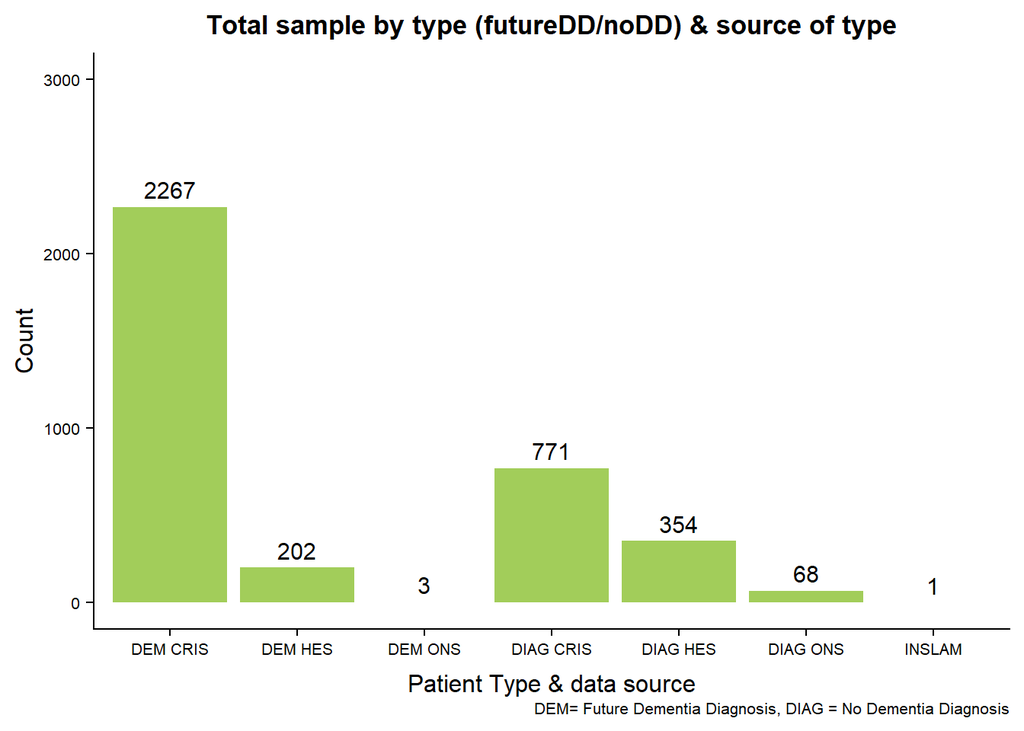

```
## The total number of patients with a scan =  3666
## The total number of patients with a Dementia diagnosis BEFORE scan =  742
## The total number of patients with a Dementia diagnosis AFTER scan =  1730
## The total number of No Dementia Diagnosis patients with their final diagnosis BEFORE scan =  72
## The total number of No Dementia Diagnosis patients with their final diagnosis AFTER scan =  1121
## The total number of patients without a diagnosis =  1
```

```r
summary_variable2 <- ddply(data,.(OUT_End_time_event), summarise, y=length(OUT_End_time_event)) %>%

  ggplot(aes(x=OUT_End_time_event,y=y,fill=OUT_End_time_event))+ #plot!
  geom_bar(stat="identity",fill="darkolivegreen3")+
  theme_cowplot()+
  geom_text(aes(label=y),vjust=-0.5,cex=4)+
  labs(x="Patient Type & data source",y="Count",caption = "DEM= Future Dementia Diagnosis, DIAG = No Dementia Diagnosis")+
  ylim(0,3000)+
  theme(plot.title=element_text(hjust=0.5,size=13),plot.caption=element_text(size=8))+
  ggtitle("Total sample by type (futureDD/noDD) & source of type")+
  theme(axis.text.x=element_text(size=8))+
  theme(axis.text.y=element_text(size=8))+
  theme(axis.title.x=element_text(size=12,vjust=-1))+
  theme(axis.title.y=element_text(size=12))

summary_variable2
```

```r
#FILTER: remove all cases those whose End Time is b4 Start Time & undiagnosed
data <- data%>%
  filter(!(FRAN_endb4start=="TRUE"))%>%
  filter(!(startsWith((.$OUT_End_time_event),"INSLAM")))
```

```
## From here onwards, we will only consider the cases with either a Dementia or (final) Non-Dementia diagnosis AFTER scan = 2851
```

### Redefine “End_Time, End_Event and Scan2End_Time” variables

As illustrated in the ‘Set End Time’ flowchart embedded a few code chunks above, the “End_Time Event” variable was defined at extraction as “choose the earliest date for a Dementia diagnosis in the following databases: CRIS, HES and ONS (in this order).” However, this means that the “End_Time Event date” is not necessarily the earliest across the three databases. For example, if a Dementia diagnosis was detected in the CRIS database, this is marked as the earliest date. However, it’s possible that there’s an earlier Dementia diagnosis date in the HES or ONS databases. Hence, revised versions of the “End_Time, End_Event and Scan2End_Time” variables are required that reflect the earliest Dementia diagnosis across the three databases (CRIS, HES, ONS). To do this I will compare the 3 dates (Dementia diagnosis dates across CRIS, HES and ONS) and choose the earliest to define the “End_Time”. But first, I will need to generate a variable that indicates Dates for Death that includes Dementia as a cause.

#### For the Dementia cases

```r
# Extract ONS Dementia Time (death by dementia)
data <- data%>%
  mutate(`FRAN_DeathbyDEM_Date`=ifelse(OUT_ONS_Death_DEM==1,OUT_ONS_DOD,NA))%>% #if death by dementia then select this date as the Date of Death (DOD)
  mutate(FRAN_DeathbyDEM_Date=as.Date(FRAN_DeathbyDEM_Date,origin="1970-01-01",optional=TRUE)) #please note different origin to Excel origin
```

```r
# Compare 3 variables containing Dementia diagnosis dates, pick oldest date, and then pick that event

FRAN_DEM_End_Time <- vector("double",length(data$OUT_CRIS_Diag_DEM_prox_ante_date))
FRAN_DEM_End_Time_Event <- vector("character",length(data$OUT_CRIS_Diag_DEM_prox_ante_date))

for (i in seq_along(data$OUT_CRIS_Diag_DEM_prox_ante_date)) {

  FRAN_DEM_End_Time[[i]] <-  suppressWarnings(min(as.numeric(c(data$OUT_CRIS_Diag_DEM_prox_ante_date[[i]],
                                           data$OUT_HES_Diag_DEM_prox_ante_date[[i]],
                                           data$FRAN_DeathbyDEM_Date[[i]])),na.rm=TRUE))

  if (FRAN_DEM_End_Time[[i]]=="Inf"){
    FRAN_DEM_End_Time[[i]] <- NA
    FRAN_DEM_End_Time_Event[[i]] <- NA
  } else {
    FRAN_DEM_End_Time_Event[[i]] <- match(FRAN_DEM_End_Time[[i]],(c(data$OUT_CRIS_Diag_DEM_prox_ante_date[[i]],
                                                                 data$OUT_HES_Diag_DEM_prox_ante_date[[i]],
                                                                 data$FRAN_DeathbyDEM_Date[[i]])))
    #in event of ties I want CRIS to precede HES, and HES to precede ONS; hence the order of variables above.
  }

}

#convert to Date (please note different origin to Excel origin)
FRAN_DEM_End_Time <- as.Date((FRAN_DEM_End_Time),origin="1970-01-01",optional=TRUE)

#convert index (1-3) to string labels
setlabels <- c("DEM CRIS", "DEM HES", "DEM ONS") #set in the order inputted above
setlevels <- c(1,2,3)#set levels = length labels
FRAN_DEM_End_Time_Event <- ordered(FRAN_DEM_End_Time_Event,levels=setlevels,labels=setlabels)
stringsAsFactors <- FALSE


## Save 2 new variables to data table
data <- cbind(data,FRAN_DEM_End_Time,FRAN_DEM_End_Time_Event)

#Add updated "scan to (first) dementia diagnosis time interval" variable (in days)
data <- data%>%
  mutate(`FRAN_scan2DEM_time` =FRAN_DEM_End_Time-Start_Time)
```

We now have 3 key new variables that indicate: i) the earliest time a Dementia diagnosis was detected across all 3 databases,“FRAN_DEM_End_Time”; ii) the database of this earliest time, “FRAN_DEM_End_Time_Event”;and iii) the time interval between the scan (start time) and the earliest Dementia diagnosis, “FRAN_scan2DEM_time”.

In a similar way to the Future Dementia Diagnosis cases, the No Dementia Diagnosis cases need to be re-evaluated. This is a similar but not identical transformation, because in the No Dementia Diagnosis cases we want to establish the End_time based on the latest (closest to today) Non-Dementia diagnostic event (as opposed to the the earliest diagnostic event, as for the Dementia cases). We do this because we want to know the date furthest away from the scan that we are confident the patient did not get a Dementia diagnosis. Before we compare the Non-Dementia Dates across CRIS, HES and ONS databases, we first need to extract the ONS Non-Dementia Date. Please note that “DIAG” = No Dementia Diagnosis.

#### For the Non-Dementia cases

```r
# Extract ONS Non-Dementia Time
data <- data%>%
  mutate(`FRAN_DeathbyOther_Date`=ifelse(OUT_ONS_Death_DEM!=1,OUT_ONS_DOD,NA))%>%
  mutate(FRAN_DeathbyOther_Date=as.Date(FRAN_DeathbyOther_Date,origin="1970-01-01",optional=TRUE)) #please note different origin to Excel origin
```

```r
# Compare 3 variables containing Non-Dementia diagnosis dates, pick most recent date, and then pick that event
FRAN_DIAG_End_Time <- vector("double",length(data$FRAN_DeathbyOther_Date))
FRAN_DIAG_End_Time_Event <- vector("character",length(data$FRAN_DeathbyOther_Date))

for (i in seq_along(data$FRAN_DeathbyOther_Date)) {

  FRAN_DIAG_End_Time[[i]] <-  suppressWarnings(max(as.numeric(c(data$FRAN_DeathbyOther_Date[[i]],
                                           data$OUT_HES_dischargedHES_dist_ante_date[[i]],
                                           data$OUT_CRIS_Diag_other_primary_dist_ante_date[[i]])),na.rm=TRUE))
  #in event of ties I want DIAG by ONS to precede HES and CRIS

  if (FRAN_DIAG_End_Time[[i]]=="Inf"){
    FRAN_DIAG_End_Time[[i]] <- NA
    FRAN_DIAG_End_Time_Event[[i]] <- NA
  } else {
    FRAN_DIAG_End_Time_Event[[i]] <- match(FRAN_DIAG_End_Time[[i]],(c(data$FRAN_DeathbyOther_Date[[i]],
                                                                   data$OUT_HES_dischargedHES_dist_ante_date[[i]],
                                                            data$OUT_CRIS_Diag_other_primary_dist_ante_date[[i]])))
  #in event of ties I want DIAG by ONS to precede HES and CRIS

  # in fact, I want to make sure that if there's death by Non-Dementia then this overrides HES and CRIS
    if (is.na(data$FRAN_DeathbyOther_Date[[i]])==0){
      FRAN_DIAG_End_Time[[i]] <- data$FRAN_DeathbyOther_Date[[i]]
      FRAN_DIAG_End_Time_Event[[i]] <- 1
    }

  }

}

#convert to Date (please note different origin to Excel origin)
FRAN_DIAG_End_Time <- as.Date((FRAN_DIAG_End_Time),origin="1970-01-01",optional=TRUE)

#convert indeces to labels
setlabels2 <- c("DIAG ONS","DIAG HES","DIAG CRIS") #set in the order inputted above. Precedence to ONS, then HES, then CRIS.
setlevels2 <- c(1,2,3)#set levels = length labels
FRAN_DIAG_End_Time_Event <- ordered(FRAN_DIAG_End_Time_Event,levels=setlevels2,labels=setlabels2)
stringsAsFactors <- FALSE

## Save 2 new variables to data table
data <- cbind(data,FRAN_DIAG_End_Time,FRAN_DIAG_End_Time_Event)

#Add updated "scan to (last) Non-Dementia diagnosis time interval" variable (in days)
data <- data%>%
  mutate(`FRAN_scan2DIAG_time` =FRAN_DIAG_End_Time-Start_Time)
```

We now have 3 additional new variables that indicate: i) the latest time a Non-Dementia diagnosis was detected across all 3 databases, “FRAN_DIAG_End_Time”; ii) the database of this latest time, “FRAN_DIAG_End_Time_Event”;and iii) the time interval between the scan (start time) and the latest Non-Dementia diagnosis, “FRAN_scan2DIAG_time”.

Next, we want to merge the 3 new Dementia and 3 new Non-Dementia variables into one set of 3 global over-arching variables: End_time, End_Event and Scan2End_time. Given that Dementia cases take precedence, we simply populate these 3 global variables using the Dementia variables unless there’s no case of dementia (“NA” Dementia cases (rows)) and hence populate with the corresponding Non-Dementia entry instead.

#### Merge FRAN_DEM with FRAN_DIAG variables into 3 global variables

```r
#Create FRAN_End_Time &  FRAN_End_Time_Event
#note: DEM events are final, so they take precedence over DIAG events. In other words, replace DEM NA events with DIAG events.

data <- data %>%
mutate(`FRAN_End_Time_Event`= ifelse(is.na(FRAN_DEM_End_Time_Event),as.character(FRAN_DIAG_End_Time_Event),as.character(FRAN_DEM_End_Time_Event)))%>%
mutate(`FRAN_End_Time`= ifelse(is.na(FRAN_DEM_End_Time_Event),as.Date(FRAN_DIAG_End_Time),as.Date(FRAN_DEM_End_Time)))

#If after merge, there are any cases labelled as NA, use original End_Time_Event labels + finally calculate "FRAN_End_scan2End"
sum(is.na(data$FRAN_End_Time_Event)) #1 case is NA
```

```
## [1] 1
```

```r
data <- data%>%
mutate(`FRAN_End_Time_Event`= ifelse(is.na(FRAN_End_Time_Event),as.character(OUT_End_time_event),as.character(FRAN_End_Time_Event)))%>%
mutate(`FRAN_End_Time`= ifelse(is.na(FRAN_End_Time_Event),OUT_End_time,FRAN_End_Time))%>%
mutate(`FRAN_End_Time`=as.Date(FRAN_End_Time,origin="1970-01-01",optional=TRUE))%>%
mutate(`FRAN_End_scan2End`= ifelse(is.na(FRAN_DEM_End_Time_Event),as.numeric(FRAN_scan2DIAG_time),as.numeric(FRAN_scan2DEM_time)))

sum(is.na(data$FRAN_End_Time_Event)) #0
```

```
## [1] 0
```

### FILTER2&3 - Medical history and 3 Months post scan

Filter#2 removes cases where a medical history of dementia (dementia diagnosis before scan) was detected and which failed to be detected at data extraction level. There were only 3 such cases. Filter#3 removes cases where time between scan and diagnosis is 3 months or less

```r
#remove 3 residual cases of patients with medical history containing dementia (identified in a separate search)
#ID1, ID2, ID3 are hidden from public view due to data privacy constraints
indexRemove <- which(data$Brcid== ID1)
data <- data[-indexRemove,]
indexRemove <- which(data$Brcid== ID2)
data <- data[-indexRemove,]
indexRemove <- which(data$Brcid== ID3)
data <- data[-indexRemove,]

#threshold by 3 months (91days: 365/12=30.41 *3= 91.25)
index=data$FRAN_End_scan2End>91
data=data[index,]
```

### Merge clinical with neuroimaging data

```r
#load brainage data
data_nan <- read.xlsx(paste(inputpath,"merge_brainage_DICOM_keyALERT.xlsx",sep=""), colNames=T, sheet="step6_essentialcolumns")

#merge with EHRs data
data <- merge(data,data_nan,all.x=T,by.x="Brcid",by.y="Brcid")
```

### FILTER4-6 & select variables: Remove missing brainage, scanner info and MMSE scores

Filter#4 removes cases with missing brainage score. Filter#5 removes cases without scanner info or not scanner A. Filter#6 removes cases with missing MMSE scores.

```r
## select & rename relevant variables
datasub1 <- cbind.data.frame(Brcid=data$Brcid,
                             nanid=data$nanid,
                             Start_Time=data$Start_Time,
                             age=data$IN_CRIS_age,
                             sex=data$IN_CRIS_sex,
                             MMSE_numerator=as.numeric(as.character(data$IN_CRIS_MMSE_numerator)),
                             MMSE_denominator=as.numeric(as.character(data$IN_CRIS_MMSE_denominator)),
                             End_Time_Event=data$FRAN_End_Time_Event,
                             End_Time=data$FRAN_End_Time,
                             End_scan2End=data$FRAN_End_scan2End,
                             brain.predictedage=data$brain.predictedage,
                             lower.CI=data$lower.CI,
                             upper.CI=data$upper.CI,
                             scanner=data$scanner,
                             normVol=data$normVol,
                             ACEnum=as.numeric(data$IN_CRIS_ACE_numeratorNEW),
                             ethnicity=as.factor(data$IN_CRIS_ethnicity))

#check for duplicates
duplicate <- duplicated(as.character(datasub1$Brcid))%>%
  datasub1[.,]

#one case is duplicated and this is manually removed in 2 hidden lines of code below (hidden due to data privacy constraints)
```

```r
## subset (i): remove patients (a)without brainage score, (b) w/o scanner info or not scanner A
datasub1b <- datasub1[which(!is.na(datasub1$brain.predictedage)&datasub1$scanner=="CNSCNSA"),]
datasub1vs1b <- anti_join(datasub1,datasub1b)
```

```
## We removed cases with i) missing brainage score & or scanner was not the same/no scanner info = 81 ii) MMSE score was missing = 165
```

```r
# subset (ii): remove cases with missing MMSE score
datasub2 <- datasub1b[which(!is.na(datasub1b$MMSE_numerator),),]


#sanity checks
{if (sum(datasub2$scanner=="CNSCNSA")!=nrow(datasub2))stop ('sanity check 1, failed')}
{if (sum(is.na(datasub2$Brcid))!=0)stop ('sanity check 2, failed')}
{if (length(unique(as.character(datasub1vs1b$Brcid)))!=nrow(datasub1vs1b))stop ('sanity check 3, failed')}
{if (length(unique(as.character(datasub2$Brcid)))!=nrow(datasub2))stop ('sanity check 4, failed')}
```

### Calculate new variables including brainPAD

```r
# group
datasub2$End_Time_Event <- as.character(datasub2$End_Time_Event)
datasub2$group <- startsWith((datasub2$End_Time_Event),"DEM") #dementia (DEM)=1, nondementia (DIAG)=0
datasub2$group <- factor(as.numeric(datasub2$group),levels=c(1,0),labels=c("futureDD","noDD"))
#R, annoyingly, recodes this to Dementia(futureDD)=1, Non-Dementia(noDD)=2 (see below)
head(datasub2$group)
```

```
## [1] noDD     noDD     noDD     futureDD noDD     futureDD
## Levels: futureDD noDD
```

```r
str(datasub2$group)
```

```
##  Factor w/ 2 levels "futureDD","noDD": 2 2 2 1 2 1 2 2 1 2 ...
```

```r
# to fix this, manually convert it using fct_rev
datasub2$group=fct_rev(datasub2$group) #use fct_rev so that Dementia=2, Non-Dementia=1


# add variables
datasub2 <- datasub2%>%
  mutate(brainPAD =datasub2$brain.predictedage-datasub2$age,
         MMSE_percentage=MMSE_numerator/MMSE_denominator*100,
         End_scan2Endyears =as.numeric(as.numeric(End_scan2End)/365))

# save
#save(datasub2, file = "datasub2_original.Rda")
```

### FILTER7: Subset data for sensitivity analyses (if applicable)

```r
if (versionname=="sensitivity1") {
  #threshold time-2-diag to min 3years
  datasub2 <- datasub2[datasub2$End_scan2Endyears>=3, ]
}else if (versionname=="sensitivity2"){
  #sensitivity analysis2: threshold MMSE to min 27
  datasub2 <- datasub2[datasub2$MMSE_numerator>=27, ]
}else if (versionname=="sensitivity3"){
  #sensitivity analysis3: threshold age to min 55
  datasub2 <- datasub2[datasub2$age>=55, ]
}
```

#### Plot by type post-filters

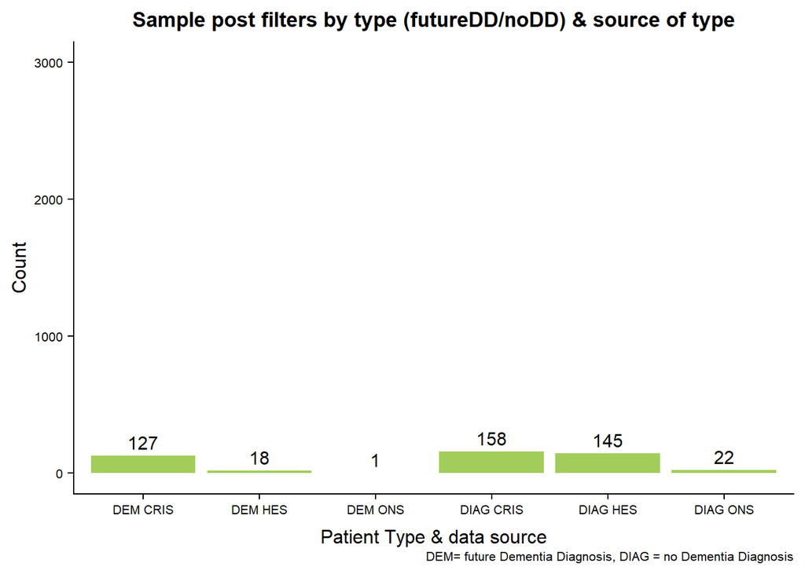

```r
summary_variable <- ddply(datasub2,.(End_Time_Event), summarise, y=length(End_Time_Event)) %>%

  ggplot(aes(x=End_Time_Event,y=y,fill=End_Time_Event))+ #plot!
  geom_bar(stat="identity",fill="darkolivegreen3")+
  theme_cowplot()+
  geom_text(aes(label=y),vjust=-0.5,cex=4)+
  labs(x="Patient Type & data source",y="Count",caption = "DEM= future Dementia Diagnosis, DIAG = no Dementia Diagnosis")+
  ylim(0,3000)+
  theme(plot.title=element_text(hjust=0.5,size=13),plot.caption=element_text(size=8))+
  ggtitle("Sample post filters by type (futureDD/noDD) & source of type")+
  theme(axis.text.x=element_text(size=8))+
  theme(axis.text.y=element_text(size=8))+
  theme(axis.title.x=element_text(size=12,vjust=-1))+
  theme(axis.title.y=element_text(size=12))

summary_variable
```

# PART 3: Descriptives

### Descriptive statistics

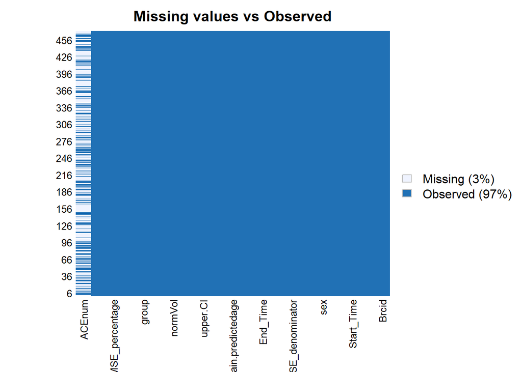

```r
#sapply(datasub2, function(x) sum(is.na(x)))            # check missingness
missmap(datasub2, main="Missing values vs Observed")    # check missingness
```

```r
uniq <- sapply(datasub2, function(x) length(unique(x)))#%>%      # check uniqueness

kbl(uniq,caption = "Uniqueness") %>%
  kable_classic(full_width = F, html_font = "Cambria",position = "left")
```

Uniqueness

|  | x |
| --- | --- |
| Brcid | 471 |
| nanid | 471 |
| Start_Time | 390 |
| age | 54 |
| sex | 2 |
| MMSE_numerator | 4 |
| MMSE_denominator | 3 |
| End_Time_Event | 6 |
| End_Time | 398 |
| End_scan2End | 397 |
| brain.predictedage | 470 |
| lower.CI | 471 |
| upper.CI | 471 |
| scanner | 1 |
| normVol | 471 |
| ACEnum | 39 |
| ethnicity | 14 |
| group | 2 |
| brainPAD | 471 |
| MMSE_percentage | 7 |
| End_scan2Endyears | 397 |

```r
#extract descriptive stats
stat_table1 <- format(stat.desc(datasub2), scientific=F) # summary
kbl(stat_table1,caption = "Descriptive Stats") %>%
  kable_classic(full_width = F, html_font = "Cambria",position = "left")%>%
  scroll_box(width = "100%", height = "100%")
```

Descriptive Stats

|  | Brcid | nanid | Start_Time | age | sex | MMSE_numerator | MMSE_denominator | End_Time_Event | End_Time | End_scan2End | brain.predictedage | lower.CI | upper.CI | scanner | normVol | ACEnum | ethnicity | group | brainPAD | MMSE_percentage | End_scan2Endyears |
| --- | --- | --- | --- | --- | --- | --- | --- | --- | --- | --- | --- | --- | --- | --- | --- | --- | --- | --- | --- | --- | --- |
| nbr.val | NA | 471.0000000 | 471.00000000 | 471.0000000 | NA | 471.00000000 | 471.000000000 | NA | 471.00000000 | 471.0000000 | 471.0000000 | 471.0000000 | 471.0000000 | NA | 471.000000000 | 170.0000000 | NA | NA | 471.0000000 | 471.00000000 | 471.00000000 |
| nbr.null | NA | 0.0000000 | 0.00000000 | 0.0000000 | NA | 0.00000000 | 0.000000000 | NA | 0.00000000 | 0.0000000 | 0.0000000 | 0.0000000 | 0.0000000 | NA | 0.000000000 | 0.0000000 | NA | NA | 0.0000000 | 0.00000000 | 0.00000000 |
| nbr.na | NA | 0.0000000 | 0.00000000 | 0.0000000 | NA | 0.00000000 | 0.000000000 | NA | 0.00000000 | 0.0000000 | 0.0000000 | 0.0000000 | 0.0000000 | NA | 0.000000000 | 301.0000000 | NA | NA | 0.0000000 | 0.00000000 | 0.00000000 |
| min | NA | 17924.0000000 | 15016.00000000 | 27.0000000 | NA | 27.00000000 | 28.000000000 | NA | 15132.00000000 | 92.0000000 | 23.2063000 | 22.2992000 | 24.1135000 | NA | 0.542294112 | 54.0000000 | NA | NA | -37.2126000 | 90.00000000 | 0.25205479 |
| max | NA | 40529.0000000 | 17984.00000000 | 91.0000000 | NA | 30.00000000 | 30.000000000 | NA | 18169.00000000 | 2785.0000000 | 91.6446000 | 90.5046000 | 92.7845000 | NA | 0.879971674 | 99.0000000 | NA | NA | 50.1047000 | 100.00000000 | 7.63013699 |
| range | NA | 22605.0000000 | 2968.00000000 | 64.0000000 | NA | 3.00000000 | 2.000000000 | NA | 3037.00000000 | 2693.0000000 | 68.4383000 | 68.2054000 | 68.6710000 | NA | 0.337677561 | 45.0000000 | NA | NA | 87.3173000 | 10.00000000 | 7.37808219 |
| sum | NA | 13587232.0000000 | 7745069.00000000 | 32523.0000000 | NA | 13356.00000000 | 14114.000000000 | NA | 8111260.00000000 | 366191.0000000 | 31885.4927000 | 31412.9950000 | 32357.9909000 | NA | 344.924126087 | 13874.0000000 | NA | NA | -637.5073000 | 44571.59277504 | 1003.26301370 |
| median | NA | 28845.0000000 | 16455.00000000 | 71.0000000 | NA | 28.00000000 | 30.000000000 | NA | 17344.00000000 | 583.0000000 | 69.4963000 | 68.3546000 | 70.5981000 | NA | 0.735303466 | 82.0000000 | NA | NA | -0.1955000 | 93.33333333 | 1.59726027 |
| mean | NA | 28847.6263270 | 16443.88322718 | 69.0509554 | NA | 28.35668790 | 29.966029724 | NA | 17221.35881104 | 777.4755839 | 67.6974367 | 66.6942569 | 68.7006176 | NA | 0.732322985 | 81.6117647 | NA | NA | -1.3535187 | 94.63183179 | 2.13007009 |
| SE.mean | NA | 250.1895780 | 33.42892427 | 0.5111875 | NA | 0.05020968 | 0.010293712 | NA | 28.56910038 | 29.1329361 | 0.5824260 | 0.5864721 | 0.5787314 | NA | 0.002730248 | 0.7037362 | NA | NA | 0.4504334 | 0.16706394 | 0.07981626 |
| CI.mean | NA | 491.6285684 | 65.68864425 | 1.0044957 | NA | 0.09866324 | 0.020227392 | NA | 56.13897283 | 57.2469236 | 1.1444812 | 1.1524318 | 1.1372212 | NA | 0.005365003 | 1.3892458 | NA | NA | 0.8851124 | 0.32828468 | 0.15684089 |
| var | NA | 29482162.5494331 | 526339.19271807 | 123.0782491 | NA | 1.18739667 | 0.049907395 | NA | 384427.13693816 | 399750.8712111 | 159.7726471 | 162.0002000 | 157.7520529 | NA | 0.003510954 | 84.1915767 | NA | NA | 95.5612859 | 13.14577968 | 3.00056950 |
| std.dev | NA | 5429.7479269 | 725.49237950 | 11.0940637 | NA | 1.08967732 | 0.223399630 | NA | 620.02188424 | 632.2585478 | 12.6401205 | 12.7279299 | 12.5599384 | NA | 0.059253300 | 9.1755968 | NA | NA | 9.7755453 | 3.62571092 | 1.73221520 |
| coef.var | NA | 0.1882217 | 0.04411929 | 0.1606649 | NA | 0.03842752 | 0.007455096 | NA | 0.03600308 | 0.8132198 | 0.1867149 | 0.1908400 | 0.1828213 | NA | 0.080911431 | 0.1124298 | NA | NA | -7.2223202 | 0.03831386 | 0.81321981 |

### Plot function

A custom function for plotting to avoid repeating code.

```r
# fplotfun inputs are data=dataset, varname=variable name, min=start range, max=end range, gap1=units bins,gap2=units xaxis, maintitle=main title, xlabt=xaxis title, fun.fun=type of plot function, vartype = 'continuous', 'discrete' or 'factorial' (defining way to present variable)

fplotfun <- function(data,varname,min,max,gap1,gap2,maintitle,xlabt, fun.fun,vartype) {

  contxaxis <- F; factxaxis <- F; discxaxis <- F

  #define function2 used in ggplot() depending if plot is continuous, discrete or factorial
  switch(vartype,
         continuous={contxaxis <- T},
         discrete={discxaxis <- T},
         factorial={factxaxis <- T},
         {stop(sprintf("The fplotfun vartype parameter %s does not exist. Define as 'continuous', 'discrete' or 'factorial'.", vartype))}
  )

  {if(contxaxis) fun.fun2 <- as.numeric}
  {if(factxaxis|discxaxis) fun.fun2 <- as.factor}

  #ggplot object
    ggplot(data,aes(x=fun.fun2(get(varname)),color=group,fill=group,group=fun.fun2(group)))+

  #ggplot condiment
    {if(contxaxis)list(fun.fun(breaks=seq(min,max,by=gap1),stat='bin',position="identity", alpha=0.5),scale_x_continuous(breaks=seq(min,max,by=gap2)))}+
    {if(discxaxis)list(fun.fun(position="identity", alpha=0.5),scale_x_discrete(breaks=seq(min,max,by=gap2),expand = expansion(add = 1.5)))} +
    {if(factxaxis)list(fun.fun(position=position_dodge(width=0.8),alpha=0.5),geom_text(stat="count",aes(label=..count..),position=position_dodge(0.9),vjust=-1,hjust=0.5,cex=2.3))} +

    theme_cowplot()+
    scale_y_continuous(expand = c(0,0,0.1,0)) +
    scale_color_manual(values=c("#666666", "#FF3300"))+
    scale_fill_manual(values=c("#666666", "#FF3300"))+
    ggtitle(maintitle)+
    xlab(xlabt)+
    theme(plot.title=element_text(hjust=0.5))+
     theme(plot.subtitle = element_text(hjust = 0.5))+
    theme(axis.text.x=element_text(size=8))+
    theme(axis.text.y=element_text(size=8))+
    theme(axis.title.x=element_text(size=12,vjust=-1))+
    theme(axis.title.y=element_text(size=12))+
    theme(plot.margin = unit(c(0.5,0.5,3,0.5), "lines"))

 }
```

### Plots, general

```r
#plots
age_plot <- fplotfun(datasub2,"age",25,100,5,10,"Age","Years",geom_area,vartype='continuous')

brainPAD_plot <- fplotfun(datasub2,"brainPAD",-50,50,5,10,"BrainPAD","Years",geom_area,vartype='continuous')

time2diag_plot <- fplotfun(datasub2,"End_scan2Endyears",0,8,1,2,"Time-to-Dementia","Years",geom_histogram,vartype='continuous')

MMSEp_plot <- fplotfun(datasub2,"MMSE_numerator",0,30,1,2,"MMSE","Score (0-30)",geom_bar,vartype='discrete')

sex_plot <- fplotfun(datasub2,"sex",0,0,0,0,"Sex","Sex",geom_bar,vartype='factorial')

normVol_plot <- fplotfun(datasub2,"normVol",0.4,0.9,0.05,0.05,"Normalised brain volume","ratio",geom_area,vartype='continuous')

ACEnum_plot <- fplotfun(datasub2,"ACEnum",0,100,5,5,"ACE","Score (0-100)",geom_histogram,vartype='continuous')+ labs(subtitle = paste( "missing data n=",sum(is.na(datasub2$ACEnum))))


#ethnicity
#rename levels to remove redundant letter
levels(datasub2$ethnicity)
```

```
##  [1] "African (N)"                    "Any other Asian background (L)"
##  [3] "Any other black background (P)" "Any other ethnic group (S)"
##  [5] "Any other mixed background (G)" "Any other white background (C)"
##  [7] "Bangladeshi (K)"                "British (A)"
##  [9] "Caribbean (M)"                  "Chinese (R)"
## [11] "Indian (H)"                     "Irish (B)"
## [13] "Not Stated (Z)"                 "NULL"
## [15] "Pakistani (J)"                  "White and Black African (E)"
## [17] "White and black Caribbean (D)"
```

```r
levels(datasub2$ethnicity) <- list("African" = "African (N)",
                                   "Any other Asian background"= "Any other Asian background (L)",
                                   "Any other black background"="Any other black background (P)",
                                   "Any other ethnic group"="Any other ethnic group (S)",
                                   "Any other mixed background"="Any other mixed background (G)",
                                   "Any other white background"="Any other white background (C)",
                                   "Bangladeshi"="Bangladeshi (K)",
                                   "British"="British (A)",
                                   "Caribbean" ="Caribbean (M)",
                                   "Chinese"="Chinese (R)",
                                   "Indian"="Indian (H)",
                                   "Irish"="Irish (B)",
                                   "Not Stated"="Not Stated (Z)",
                                   "NULL"="NULL",
                                   "Pakistani"="Pakistani (J)",
                                   "White and Black African"= "White and Black African (E)",
                                   "White and Black Caribbean" ="White and black Caribbean (D)")

levels(datasub2$ethnicity)
```

```
##  [1] "African"                    "Any other Asian background"
##  [3] "Any other black background" "Any other ethnic group"
##  [5] "Any other mixed background" "Any other white background"
##  [7] "Bangladeshi"                "British"
##  [9] "Caribbean"                  "Chinese"
## [11] "Indian"                     "Irish"
## [13] "Not Stated"                 "NULL"
## [15] "Pakistani"                  "White and Black African"
## [17] "White and Black Caribbean"
```

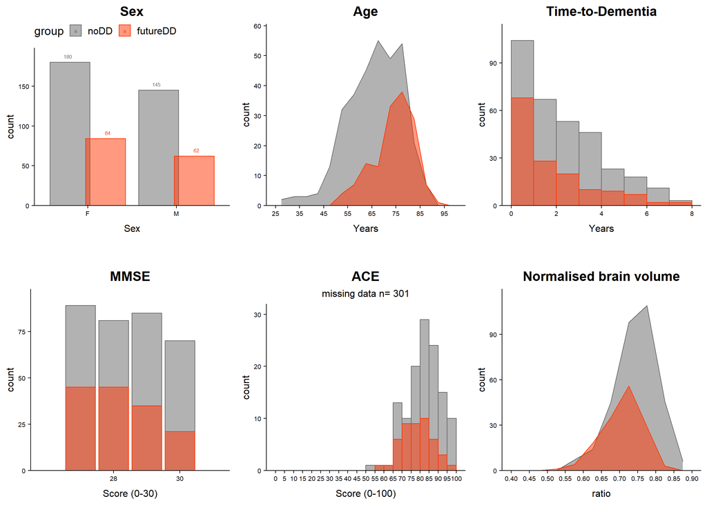

```r
ethnicity_plot <- ggplot(datasub2,aes(x=as.factor(ethnicity)))+
  geom_bar(position=position_dodge(width=0.8),alpha=0.5,fill="blue")+
  geom_text(stat="count",aes(label=..count..),position=position_dodge(0.9),vjust=-1,hjust=0.5,cex=2.3) +
   theme_cowplot()+
    scale_y_continuous(expand = c(0,0,0.1,0)) +
    ggtitle("Ethnicity")+
    xlab("Ethnicity")+
    theme(plot.title=element_text(hjust=0.5))+
    theme(plot.subtitle = element_text(hjust = 0.5))+
    theme(axis.text.x=element_text(size=8,angle=90))+
    theme(axis.text.y=element_text(size=8))+
    theme(axis.title.x=element_text(size=12,vjust=-1))+
    theme(axis.title.y=element_text(size=12))+
    theme(plot.margin = unit(c(0.5,0.5,3,0.5), "lines"))


# plot together using cowplot function
all_plots <- cowplot::plot_grid(sex_plot+ theme(legend.position = "top"),age_plot+ theme(legend.position = "none"),
                                time2diag_plot+ theme(legend.position = "none"),MMSEp_plot+ theme(legend.position = "none"),
                                ACEnum_plot+ theme(legend.position = "none"),normVol_plot+ theme(legend.position = "none"),
                                labels = "", nrow = 2)


all_plots
```

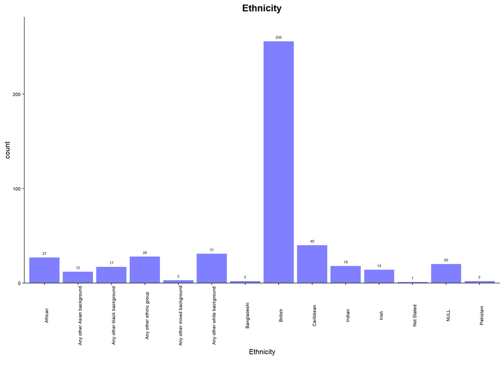

```r
ethnicity_plot
```

```r
#NOTE: for brainPAD plot, see Fig 2

#save pic
filename <- paste(outputpath,"Fig0_allplots_",versionname,".tif",sep="")
ggsave(filename = filename,height = 9, width = 12, print(all_plots, newpage = FALSE), device = "tiff", dpi = picres, units = "in")

filename <- paste(outputpath,"Fig0_ethnicity",versionname,".tif",sep="")
ggsave(filename = filename,height = 4.5, width = 8, print(ethnicity_plot, newpage = FALSE), device = "tiff", dpi = picres, units = "in")
```

### Figure 2: brain-age vs chronological age scatterplot

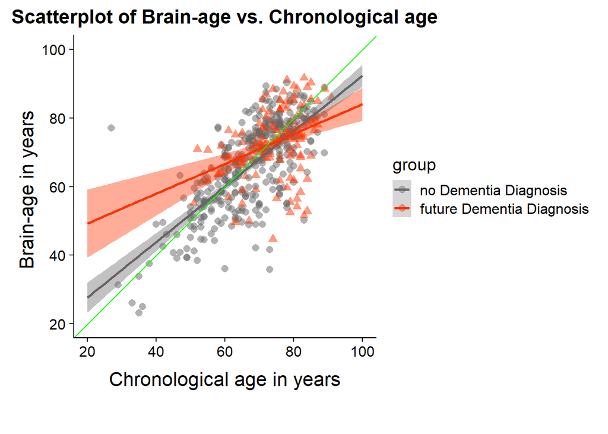

```r
brainage_plot1 <- ggplot(datasub2,aes(x=as.numeric(age),y=as.numeric(brain.predictedage), color=group, fill=group,shape=group))+

  geom_point(position="identity", alpha=0.5, size=2.5 )+
  coord_fixed(ratio=1)+theme_cowplot()+
  geom_smooth(method='lm',se=TRUE,fullrange=TRUE)+
  geom_abline(slope =1,intercept=0,color='green')+
  scale_x_continuous(breaks=seq(20,100,by=10))+
  scale_y_continuous(breaks=seq(20,100,by=10))+
  theme(plot.title=element_text(hjust=0.5))+
  scale_color_manual(values=c("#666666", "#FF3300"),labels = c("no Dementia Diagnosis", "future Dementia Diagnosis"))+
  scale_fill_manual(values=c("#666666", "#FF3300"))+
  xlim(20,100)+ylim(20,100)+
  ggtitle("Scatterplot of Brain-age vs. Chronological age")+
  xlab("Chronological age in years")+ ylab("Brain-age in years ")+
  theme(axis.text.x=element_text(size=12))+
  theme(axis.text.y=element_text(size=12))+
  theme(axis.title.x=element_text(size=16,vjust=-1))+
  theme(axis.title.y=element_text(size=16))+
  theme(plot.margin = unit(c(0.5,0.5,3,0.5), "lines"))+
  guides(fill = FALSE,color=guide_legend("group"),shape=F)

brainage_plot1
```

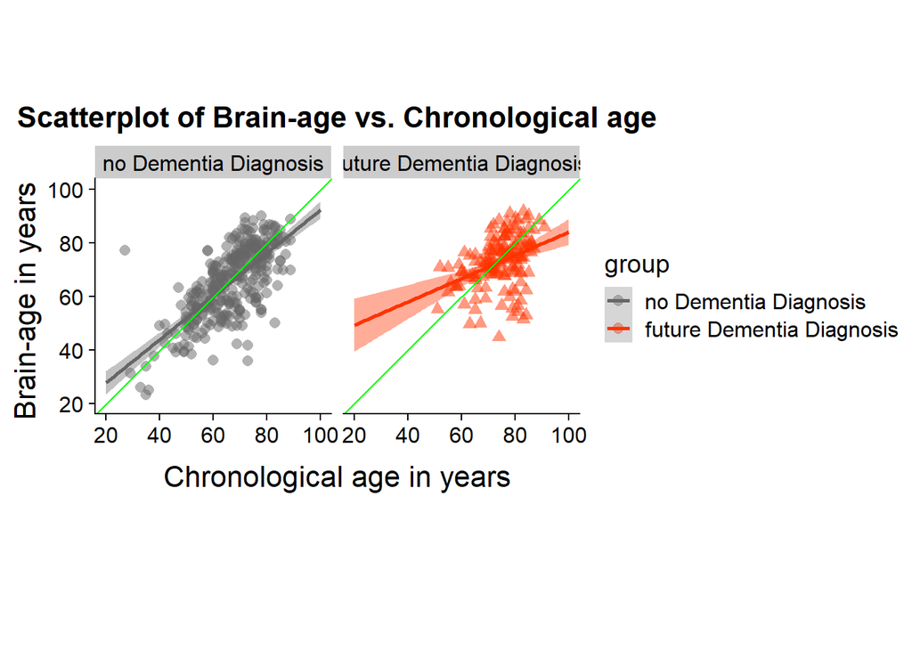

```r
###modify legend labels in facet_grid below
legend_names <- list(
  'noDD'="no Dementia Diagnosis",
  'futureDD'="future Dementia Diagnosis"
)
DD_labeller <- function(variable,value){
  return(legend_names[value])
}


brainage_plot2 <- brainage_plot1 + facet_grid(. ~ group,labeller=DD_labeller)
brainage_plot2
```

```r
# save
filename <- paste(outputpath,"Fig2_facet_scatter_brainage_",versionname,".tif",sep="")
ggsave(brainage_plot2,width=300, height=300, dpi=picres, device = "tiff",filename = filename,units = 'mm')
```

### Figure 3: brain-PAD vs chronological age scatterplot

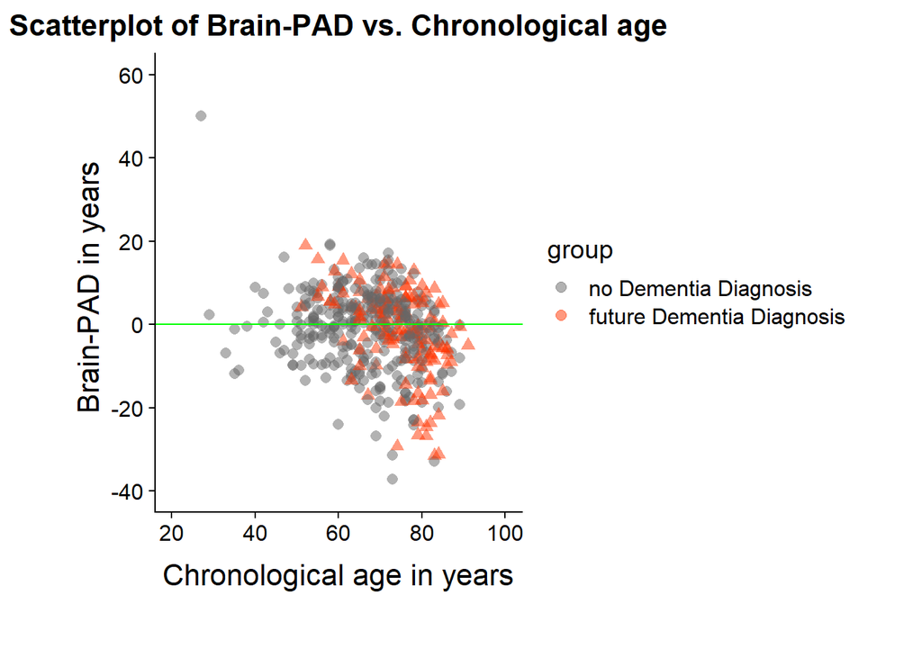

```r
brainPAD_plot2 <- ggplot(datasub2,aes(x=as.numeric(age),y=as.numeric(brainPAD), color=group, fill=group,shape=group))+

  geom_point(position="identity", alpha=0.5, size=2.5 )+
  coord_fixed(ratio=1)+theme_cowplot()+
  #geom_smooth(method='lm',se=TRUE,fullrange=TRUE)+
  geom_abline(slope =0,intercept=0,color='green')+
  scale_x_continuous(breaks=seq(20,100,by=10))+
  scale_y_continuous(breaks=seq(-40,60,by=10))+
  theme(plot.title=element_text(hjust=0.5))+
  scale_color_manual(values=c("#666666", "#FF3300"),labels = c("no Dementia Diagnosis", "future Dementia Diagnosis"))+
  scale_fill_manual(values=c("#666666", "#FF3300"))+
  xlim(20,100)+ylim(-40,60)+
  ggtitle("Scatterplot of Brain-PAD vs. Chronological age")+
  xlab("Chronological age in years")+ ylab("Brain-PAD in years ")+
  theme(axis.text.x=element_text(size=12))+
  theme(axis.text.y=element_text(size=12))+
  theme(axis.title.x=element_text(size=16,vjust=-1))+
  theme(axis.title.y=element_text(size=16))+
  theme(plot.margin = unit(c(0.5,0.5,3,0.5), "lines"))+
  guides(fill = FALSE,color=guide_legend("group"),shape=F)

brainPAD_plot2
```

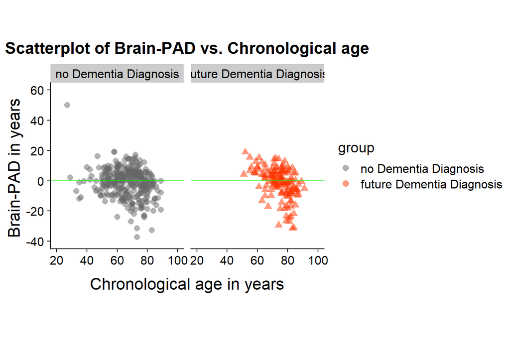

```r
brainPAD_plot3 <- brainPAD_plot2 + facet_grid(. ~ group,labeller=DD_labeller)
brainPAD_plot3
```

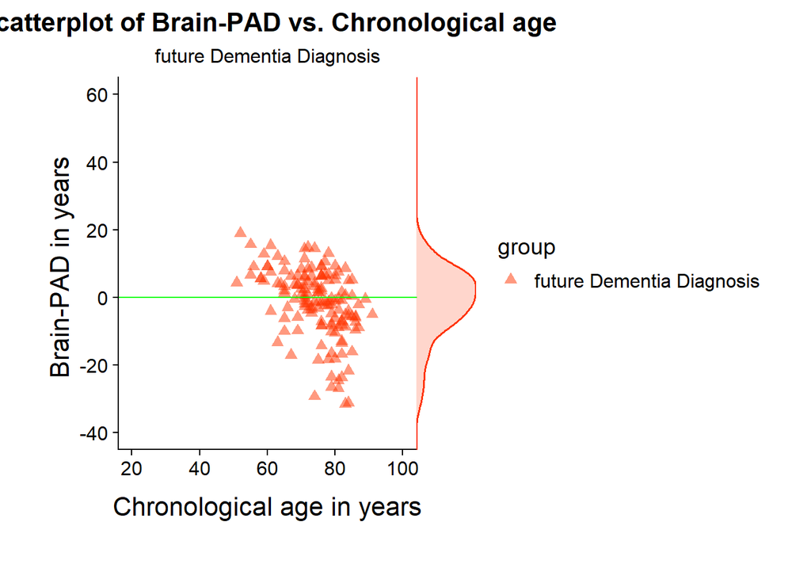

```r
# save
filename <- paste(outputpath,"Fig3_facet_scatter_brainPAD_",versionname,".tif",sep="")
ggsave(brainPAD_plot3,width=300, height=300, dpi=picres, device = "tiff",filename = filename,units = 'mm')


####################
# Marginal densities along y axis
# Need to set coord_flip = TRUE, if you plan to use coord_flip()
ydens <- axis_canvas(brainPAD_plot2, axis = "y", coord_flip = TRUE)+
  geom_density(data= datasub2, aes(x = brainPAD, fill = group, colour=group),
               alpha = 0.2, size = 0.7)+
  coord_flip()+
  scale_fill_manual(values=c("#666666", "#FF3300"))+
  scale_color_manual(values=c("#666666", "#FF3300"))



p2 <- insert_yaxis_grob(brainPAD_plot2, ydens, grid::unit(.2, "null"), position = "right")
#ggdraw(p2)


################### separate plots + density plots
#subset data
  datasub2D <- datasub2[datasub2$group =='futureDD',]
  datasub2noD <- datasub2[datasub2$group =='noDD',]

#Dementia ggroup
brainPAD_plot2a <- ggplot(datasub2D,aes(x=as.numeric(age),y=as.numeric(brainPAD), color=group, fill=group,shape=group))+

  geom_point(position="identity", alpha=0.5, size=2.5, shape=17 )+
  coord_fixed(ratio=1)+theme_cowplot()+
  #geom_smooth(method='lm',se=TRUE,fullrange=TRUE)+
  geom_abline(slope =0,intercept=0,color='green')+
  scale_x_continuous(breaks=seq(20,100,by=10))+
  scale_y_continuous(breaks=seq(-40,60,by=10))+
  theme(plot.title=element_text(hjust=0.5))+
  scale_color_manual(values=c("#FF3300"),labels = c("future Dementia Diagnosis"))+
  scale_fill_manual(values=c("#FF3300"))+
  xlim(20,100)+ylim(-40,60)+
  ggtitle("Scatterplot of Brain-PAD vs. Chronological age")+
  labs(subtitle = "future Dementia Diagnosis")+
  theme(plot.subtitle = element_text(hjust = 0.5))+
  xlab("Chronological age in years")+ ylab("Brain-PAD in years ")+
  theme(axis.text.x=element_text(size=12))+
  theme(axis.text.y=element_text(size=12))+
  theme(axis.title.x=element_text(size=16,vjust=-1))+
  theme(axis.title.y=element_text(size=16))+
  theme(plot.margin = unit(c(0.5,0.5,3,0.5), "lines"))+
  guides(fill = FALSE,color=guide_legend("group"),shape=F)

#brainPAD_plot2a

####################
# Marginal densities along y axis
# Need to set coord_flip = TRUE, if you plan to use coord_flip()
ydens2 <- axis_canvas(brainPAD_plot2a, axis = "y", coord_flip = TRUE)+
  geom_density(data= datasub2D, aes(x = brainPAD, fill = group, colour=group),
               alpha = 0.2, size = 0.7)+
  coord_flip()+
  scale_fill_manual(values=c("#FF3300"))+
  scale_color_manual(values=c("#FF3300"))

brainPAD_plot2ai<- insert_yaxis_grob(brainPAD_plot2a, ydens, grid::unit(.2, "null"), position = "right")
#ggdraw(brainPAD_plot2ai)

brainPAD_plot2aii <- insert_yaxis_grob(brainPAD_plot2a, ydens2, grid::unit(.2, "null"), position = "right")
ggdraw(brainPAD_plot2aii)
```

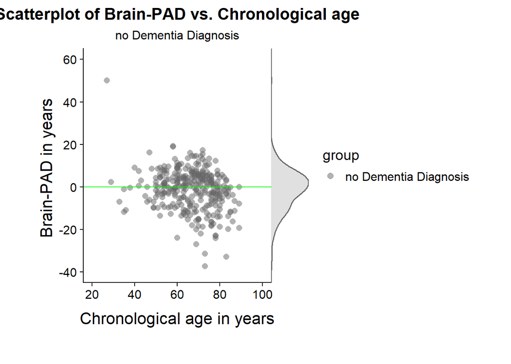

```r
#no Dementia group
brainPAD_plot2b <- ggplot(datasub2noD,aes(x=as.numeric(age),y=as.numeric(brainPAD), color=group, fill=group,shape=group))+

  geom_point(position="identity", alpha=0.5, size=2.5 )+
  coord_fixed(ratio=1)+theme_cowplot()+
  #geom_smooth(method='lm',se=TRUE,fullrange=TRUE)+
  geom_abline(slope =0,intercept=0,color='green')+
  scale_x_continuous(breaks=seq(20,100,by=10))+
  scale_y_continuous(breaks=seq(-40,60,by=10))+
  theme(plot.title=element_text(hjust=0.5))+
  scale_color_manual(values=c("#666666"),labels = c("no Dementia Diagnosis"))+
  scale_fill_manual(values=c("#666666"))+
  xlim(20,100)+ylim(-40,60)+
  ggtitle("Scatterplot of Brain-PAD vs. Chronological age")+
  labs(subtitle = "no Dementia Diagnosis")+
  theme(plot.subtitle = element_text(hjust = 0.5))+
  xlab("Chronological age in years")+ ylab("Brain-PAD in years ")+
  theme(axis.text.x=element_text(size=12))+
  theme(axis.text.y=element_text(size=12))+
  theme(axis.title.x=element_text(size=16,vjust=-1))+
  theme(axis.title.y=element_text(size=16))+
  theme(plot.margin = unit(c(0.5,0.5,3,0.5), "lines"))+
  guides(fill = FALSE,color=guide_legend("group"),shape=F)

#brainPAD_plot2b

####################
# Marginal densities along y axis
# Need to set coord_flip = TRUE, if you plan to use coord_flip()
ydens3 <- axis_canvas(brainPAD_plot2b, axis = "y", coord_flip = TRUE)+
  geom_density(data= datasub2noD, aes(x = brainPAD, fill = group, colour=group),
               alpha = 0.2, size = 0.7)+
  coord_flip()+
  scale_fill_manual(values=c("#666666"))+
  scale_color_manual(values=c("#666666"))

brainPAD_plot2bii<- insert_yaxis_grob(brainPAD_plot2b, ydens3, grid::unit(.2, "null"), position = "right")
ggdraw(brainPAD_plot2bii)
```

```r
wh=200 #width and height
# save
filename <- paste(outputpath,"Fig3aBOUND_scatter_brainPAD_withdensity_futureDD_",versionname,".tif",sep="")
ggsave(brainPAD_plot2ai,width=wh, height=wh, dpi=picres, device = "tiff",filename = filename,units = 'mm')

filename <- paste(outputpath,"Fig3bBOUND_scatter_brainPAD_withdensity_noDD_",versionname,".tif",sep="")
ggsave(brainPAD_plot2b,width=wh, height=wh, dpi=picres, device = "tiff",filename = filename,units = 'mm')


filename <- paste(outputpath,"Fig3aSEP_scatter_brainPAD_withdensity_futureDD_",versionname,".tif",sep="")
ggsave(brainPAD_plot2aii,width=wh, height=wh, dpi=picres, device = "tiff",filename = filename,units = 'mm')

filename <- paste(outputpath,"Fig3bSEP_scatter_brainPAD_withdensity_noDD_",versionname,".tif",sep="")
ggsave(brainPAD_plot2bii,width=wh, height=wh, dpi=picres, device = "tiff",filename = filename,units = 'mm')
```

### Table 1 function

```r
ftablefun <- function(data,bygroup) {
options(scipen = 999)

# extract the precise summary stats I want
table_summary <- data %>%
  # select variables you want in demographics table
  select(group, age, sex, MMSE_numerator, End_scan2Endyears,ACEnum,normVol) %>%

  # calculate demographics by group if applicable
  {if(bygroup) group_by(.,group) else .}%>%

  # get summary statistics
  summarise(N = n(),
            NFEMALE = sum(sex == "F"),
            NMALE = sum(sex == "M"),
            PFEMALE= (NFEMALE/(NFEMALE+NMALE)*100),
            AGE_PCOUNT=(((sum(!is.na(age)))/N)*100),
            AGE_MEAN = mean(age,na.rm=TRUE),
            AGE_SD=sd(age,na.rm=TRUE),
            AGE_MIN=min(age,na.rm=TRUE),
            AGE_MAX=max(age,na.rm=TRUE),
            AGE_MD=median(age,na.rm=TRUE),
            TIME_PCOUNT=(((sum(!is.na(End_scan2Endyears)))/N)*100),
            TIME_MEAN = mean(End_scan2Endyears,na.rm=TRUE),
            TIME_SD=sd(End_scan2Endyears,na.rm=TRUE),
            TIME_MIN=min(End_scan2Endyears,na.rm=TRUE),
            TIME_MAX=max(End_scan2Endyears,na.rm=TRUE),
            TIME_MD=median(End_scan2Endyears,na.rm=TRUE),
            MMSE_PCOUNT=(((sum(!is.na(MMSE_numerator)))/N)*100),
            MMSE_MEAN = mean(MMSE_numerator,na.rm=TRUE),
            MMSE_SD=sd(MMSE_numerator,na.rm=TRUE),
            MMSE_MIN=min(MMSE_numerator,na.rm=TRUE),
            MMSE_MAX=max(MMSE_numerator,na.rm=TRUE),
            MMSE_MD=median(MMSE_numerator,na.rm=TRUE),
            ACE_PCOUNT=(((sum(!is.na(ACEnum)))/N)*100),
            ACE_MEAN = mean(ACEnum,na.rm=TRUE),
            ACE_SD=sd(ACEnum,na.rm=TRUE),
            ACE_MIN=min(ACEnum,na.rm=TRUE),
            ACE_MAX=max(ACEnum,na.rm=TRUE),
            ACE_MD=median(ACEnum,na.rm=TRUE),
            NVOL_PCOUNT=(((sum(!is.na(normVol)))/N)*100),
            NVOL_MEAN = mean(normVol,na.rm=TRUE),
            NVOL_SD=sd(normVol,na.rm=TRUE),
            NVOL_MIN=min(normVol,na.rm=TRUE),
            NVOL_MAX=max(normVol,na.rm=TRUE),
            NVOL_MD=median(normVol,na.rm=TRUE))

# add group column if missing
{if(bygroup==F) table_summary$group <- 'All'}


# Table1 part A - round to 2d.p
tableA <- table_summary %>%

  # Round-up measures to 2 dp
  mutate_at(c("PFEMALE","AGE_PCOUNT","AGE_MEAN","AGE_SD","AGE_MIN","AGE_MAX","AGE_MD",
            "TIME_PCOUNT","TIME_MEAN","TIME_SD","TIME_MIN","TIME_MAX","TIME_MD",
            "MMSE_PCOUNT","MMSE_MEAN","MMSE_SD","MMSE_MIN","MMSE_MAX","MMSE_MD",
            "ACE_PCOUNT","ACE_MEAN","ACE_SD","ACE_MIN","ACE_MAX","ACE_MD","NVOL_PCOUNT"), ~format(round(., 2), nsmall = 2))%>%

  # Create new variables and paste the mean and sd together as a string to have Mean (SD) in the same table cell
  mutate(`Female %` = paste(PFEMALE),
        `Age Complete cases %` = paste(AGE_PCOUNT),
        `Age Mean (SD)` = paste(AGE_MEAN, paste(" (", AGE_SD, ") ", sep = "")),
        `Age Median` = paste(AGE_MD),
        `Age Min-Max` = paste(AGE_MIN,"-",AGE_MAX, sep = ""),

        `MMSE Complete cases %` = paste(MMSE_PCOUNT),
        `MMSE Mean (SD)` = paste(MMSE_MEAN, paste(" (", MMSE_SD, ") ", sep = "")),
        `MMSE Median` = paste(MMSE_MD),
        `MMSE Min-Max` = paste(MMSE_MIN,"-",MMSE_MAX, sep = ""),

        `Time-to-Event Complete cases %` = paste(TIME_PCOUNT),
        `Time-to-Event Mean (SD)` = paste(TIME_MEAN, paste(" (", TIME_SD, ") ", sep = "")),
        `Time-to-Event Median` = paste(TIME_MD),
        `Time-to-Event Min-Max` = paste(TIME_MIN,"-",TIME_MAX, sep = ""),

        `ACE Complete cases %` = paste(ACE_PCOUNT),
        `ACE Mean (SD)` = paste(ACE_MEAN, paste(" (", ACE_SD, ") ", sep = "")),
        `ACE Median` = paste(ACE_MD),
        `ACE Min-Max` = paste(ACE_MIN,"-",ACE_MAX, sep = ""),

         `Normalised Brain Volume Complete cases %` = paste(NVOL_PCOUNT),)%>%

  # select our presentable variables for the table
  select(`Group`=group,
         N, `Female %`,
         `Age Complete cases %` ,`Age Mean (SD)`, `Age Median`, `Age Min-Max`,
         `MMSE Complete cases %`,`MMSE Mean (SD)`,`MMSE Median`,`MMSE Min-Max`,
         `Time-to-Event Complete cases %`,`Time-to-Event Mean (SD)`,`Time-to-Event Median`,`Time-to-Event Min-Max`,
         `ACE Complete cases %`,`ACE Mean (SD)` ,`ACE Median`,`ACE Min-Max`,`Normalised Brain Volume Complete cases %`)


# Table2 part B - round to 4d.p
tableB <- table_summary %>%

  # Round-up measures to 4dp
  mutate_at(c("NVOL_MEAN","NVOL_SD","NVOL_MIN","NVOL_MAX","NVOL_MD"), ~format(round(., 4), nsmall = 4))%>%

  # Create new variables and paste the mean and sd together as a string to have Mean (SD) in the same table cell
  mutate(`Normalised Brain Volume Mean (SD)` = paste(NVOL_MEAN, paste(" (", NVOL_SD, ") ", sep = "")),
        `Normalised Brain Volume Median` = paste(NVOL_MD),
        `Normalised Brain Volume Min-Max` = paste(NVOL_MIN,"-",NVOL_MAX, sep = ""),)%>%


  # select our presentable variables for the table
  select(`Normalised Brain Volume Mean (SD)` ,`Normalised Brain Volume Median`,`Normalised Brain Volume Min-Max`)

# Bind tables A and B
tableAB <- cbind(tableA,tableB)

# These are some options for the pander library to output the table
panderOptions('table.split.table', 100)

# this command outputs the table with the caption
#pander(tableAB)
options(scipen = 0)
return (tableAB)
}
```

### Table 1: data characteristics

```r
table1 <- ftablefun(datasub2,bygroup=F)
table2 <- ftablefun(datasub2,bygroup=T)

# Bind tables 1 &2
table3 <- rbind(table1,table2)


#transpose & adjust col names
table3t <- t(table3)%>%
as.data.table(., keep.rownames = T)
cnames <- as.character(table3t[1, ])
colnames(table3t) <- cnames
table3t <- table3t[-1, ]

#run t-tests for relevant variables
ttest_AGE <- t.test(datasub2$age~datasub2$group)
ttest_MMSE <- t.test(datasub2$MMSE_numerator~datasub2$group)
ttest_TIME <- t.test(datasub2$End_scan2Endyears~datasub2$group)
ttest_ACE <- t.test(datasub2$ACEnum~datasub2$group)
ttest_NVOL <- t.test(datasub2$normVol~datasub2$group)

#create num version of sex variable
datasub2 <- datasub2%>%
  mutate('sexNum'=as.factor(sex))%>%
  mutate('sexNum'=as.numeric(sexNum))

#wtest_SEX <- wilcox.test(as.numeric(sex)~group,data=datasub2) #report median
wtest_SEX <- wilcox.test(sexNum~group,data=datasub2) #report median

#add column
table4 <- table3t %>%
  add_column('noDD vs. futureDD (p-value)' = 'NA', .after = "futureDD")


#write function to convert p-values: round to 4dp and if lower than 0.0001 to '<0.0001'
col_pval <- function(df) {
  output <- vector("double", length(df))
  for (i in seq_along(df)) {
    if(as.numeric(df[[i]]) < 0.0001){
      output[i] <- ("<0.0001")
    } else {
      output[i] <- format(round(df[[i]], 4), nsmall = 4)
    }
  }
  output
}


#fill column with t/w-test p-values
table4[table4$Group=="Age Mean (SD)",'noDD vs. futureDD (p-value)'] <- col_pval(ttest_AGE$p.value)
table4[table4$Group=="MMSE Mean (SD)",'noDD vs. futureDD (p-value)'] <- col_pval(ttest_MMSE$p.value)
table4[table4$Group=="ACE Mean (SD)",'noDD vs. futureDD (p-value)'] <- col_pval(ttest_ACE$p.value)
table4[table4$Group=="Normalised Brain Volume Mean (SD)",'noDD vs. futureDD (p-value)'] <- col_pval(ttest_NVOL$p.value)
table4[table4$Group=="Female %",'noDD vs. futureDD (p-value)'] <- col_pval(wtest_SEX$p.value)

# These are some options for the pander library to output the table
panderOptions('table.split.table', 150)
# this command outputs the table with the caption
pander(table4 , caption = "(1) Sample characteristics")
```

(1) Sample characteristics

| Group | All | noDD | futureDD | noDD vs. futureDD (p-value) |
| --- | --- | --- | --- | --- |
| N | 471 | 325 | 146 | NA |
| Female % | 56.05 | 55.38 | 57.53 | 0.6644 |
| Age Complete cases % | 100.00 | 100.00 | 100.00 | NA |
| Age Mean (SD) | 69.05 (11.09) | 66.66 (11.39) | 74.38 ( 8.23) | <0.0001 |
| Age Median | 71.00 | 68.00 | 76.00 | NA |
| Age Min-Max | 27.00-91.00 | 27.00-89.00 | 51.00-91.00 | NA |
| MMSE Complete cases % | 100.00 | 100.00 | 100.00 | NA |
| MMSE Mean (SD) | 28.36 (1.09) | 28.42 (1.11) | 28.22 (1.04) | 0.0605 |
| MMSE Median | 28.00 | 28.00 | 28.00 | NA |
| MMSE Min-Max | 27.00-30.00 | 27.00-30.00 | 27.00-30.00 | NA |
| Time-to-Event Complete cases % | 100.00 | 100.00 | 100.00 | NA |
| Time-to-Event Mean (SD) | 2.13 (1.73) | 2.28 (1.73) | 1.79 (1.69) | NA |
| Time-to-Event Median | 1.60 | 1.76 | 1.20 | NA |
| Time-to-Event Min-Max | 0.25-7.63 | 0.25-7.63 | 0.25-7.49 | NA |
| ACE Complete cases % | 36.09 | 38.15 | 31.51 | NA |
| ACE Mean (SD) | 81.61 (9.18) | 82.64 (9.22) | 78.85 (8.56) | 0.0139 |
| ACE Median | 82.00 | 83.00 | 79.50 | NA |
| ACE Min-Max | 54.00-99.00 | 54.00-99.00 | 59.00-96.00 | NA |
| Normalised Brain Volume Complete cases % | 100.00 | 100.00 | 100.00 | NA |
| Normalised Brain Volume Mean (SD) | 0.7323 (0.0593) | 0.7437 (0.0587) | 0.7071 (0.0523) | <0.0001 |
| Normalised Brain Volume Median | 0.7353 | 0.7494 | 0.7127 | NA |
| Normalised Brain Volume Min-Max | 0.5423-0.8800 | 0.5590-0.8800 | 0.5423-0.8176 | NA |

```r
#save table to file for export
filename <- paste(outputpath,"Table1_",versionname,".xlsx",sep="")
write.xlsx(table4,filename, rowNames=T, colNames=T)
```

# PART 4: Statistical Analysis

## Logistic Regression

```r
flogregfun <- function(data,Center,Scale,Poly) {

temp_data <- data%>%
  select(group, age, sex, MMSE_numerator, brainPAD, normVol)%>%
  mutate(`MMSE`=MMSE_numerator,
           MMSE_numerator=NULL)%>%

  {if(Poly) mutate(.,`age`=poly(age,2)[,1],`age2`=poly(age,2)[,2]) else .}%>%
  {if(Poly) relocate(.,age2, .after = age) else .}%>%
  mutate_if(is.numeric,~scale(.,center=Center,scale=Scale),na.rm = TRUE)


temp_model_log <- temp_data %>%
  glm(group ~.,family=binomial(link='logit'),data=.)
return(temp_model_log)
}

# run #Center, Scale and Poly settings set at start of code
model_log <- flogregfun (datasub2,Center=fCenter,Scale=fScale,Poly=fPoly)
summary(model_log)
```

```
##
## Call:
## glm(formula = group ~ ., family = binomial(link = "logit"), data = .)
##
## Deviance Residuals:
##     Min       1Q   Median       3Q      Max
## -1.6315  -0.8974  -0.5363   1.1152   2.4085
##
## Coefficients:
##             Estimate Std. Error z value Pr(>|z|)
## (Intercept) -0.85485    0.15565  -5.492 3.97e-08 ***
## age         18.00966    4.11677   4.375 1.22e-05 ***
## age2        -1.86911    3.82990  -0.488 0.625528
## sexM        -0.37601    0.22450  -1.675 0.093962 .
## brainPAD     0.02264    0.01177   1.924 0.054405 .
## normVol     -7.52174    2.15037  -3.498 0.000469 ***
## MMSE        -0.05609    0.10236  -0.548 0.583705
## ---
## Signif. codes:  0 '***' 0.001 '**' 0.01 '*' 0.05 '.' 0.1 ' ' 1
##
## (Dispersion parameter for binomial family taken to be 1)
##
##     Null deviance: 583.18  on 470  degrees of freedom
## Residual deviance: 508.84  on 464  degrees of freedom
## AIC: 522.84
##
## Number of Fisher Scoring iterations: 5
```

```r
# anova(model_log, test="Chisq")
# PseudoR2(model_log,c("McFadden","Nagel"))
```

### Test assumptions of Logit

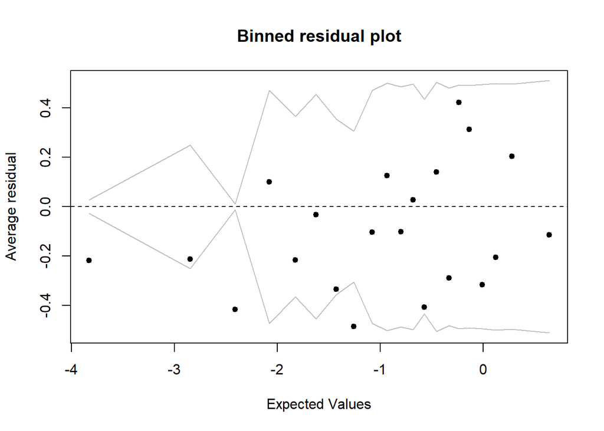

```r
# ##### test if the distribution of residuals of Logit is normal
# #instead use binned distribution via binnedplot function (residuals should be within bound)
# #https://www.rdocumentation.org/packages/arm/versions/1.11-2/topics/binnedplot
# #https://easystats.github.io/performance/reference/binned_residuals.html
 x <- predict(model_log)
 y <- resid(model_log)
 binnedplot(x,y)
```

### Table 2 function

```r
flogtablefun <- function(data,type,Center,Scale,Poly){

  #recode type
  if (type=='log') {
    log <- T
  } else if ( type=='cox') {
    log <- F
  } else {
    stop(sprintf("Define second parameter, type, as either 'log' or 'cox'"))
  }


  #run logistic/cox regression function accordingly
  {if(log)  model <- flogregfun (data,Center,Scale,Poly) else model <- fcoxregfun (data,Center,Scale,Poly)[[1]]}

  #version labels
  if(Poly) {
    polystatus <- ' with quadratic age (polynomial)'
    polyshort <- 'PolyT'
  } else {
    polystatus <- ' without quadratic age'
    polyshort <- 'PolyF'
  }

  if (Center==T&Scale==T) {
    centeringstatus <- 'standardized'
    centeringshort <- 'CentZ'
  } else if ( Center==T&Scale==F) {
    centeringstatus <- 'centred'
    centeringshort <- 'CentT'
  } else if ( Center==F&Scale==F) {
    centeringstatus <- 'not-centred'
    centeringshort <- 'CentF'
  } else {
    stop(sprintf("Variable transformation in flogregfun embedded in this function can be either uncentred, centred or standardized (z-scores)"))
  }

  options(scipen = 999) #turn scientific notation off


  #select variables
  #first extract main stats from model
  modelcoef <- exp(coefficients(model))
  modelcoefCI <- exp(confint(model,level=0.95))
  {if(log) modelpvalues <- coef(summary(model))[,4] else modelpvalues <- coef(summary(model))[,5] }

  # then define variables
  #n/N (n=dementia case, N=total cases)
  {if(log) MOD_N <- nrow(model$data) else MOD_N <- model$n}
  {if(log) MOD_n <- sum(str_starts(model$data[['group']], pattern="futureDD", negate = FALSE)) else MOD_n <- model$nevent}

   #OR (odds ratio)
  MOD_ageCF <- modelcoef["age"]
  {if(Poly) MOD_age2CF <- modelcoef["age2"] }
  MOD_sexCF <- modelcoef["sexM"]
  MOD_brainPADCF <- modelcoef["brainPAD"]
  MOD_MMSECF <- modelcoef["MMSE"]
  MOD_normVolCF <- modelcoef["normVol"]

  {if(Poly) MOD_OR <- cbind.data.frame(MOD_ageCF,MOD_age2CF,MOD_sexCF,MOD_brainPADCF,MOD_MMSECF,MOD_normVolCF) else MOD_OR <- cbind.data.frame(MOD_ageCF,MOD_sexCF,MOD_brainPADCF,MOD_MMSECF,MOD_normVolCF) }

  #CI_OR lower
  MOD_ageCIlow <- modelcoefCI["age",1]
  {if(Poly) MOD_age2CIlow <- modelcoefCI["age2",1] }
  MOD_sexCIlow <- modelcoefCI["sexM",1]
  MOD_brainPADCIlow <- modelcoefCI["brainPAD",1]
  MOD_MMSECIlow <- modelcoefCI["MMSE",1]
  MOD_normVolCIlow <- modelcoefCI["normVol",1]

  {if(Poly)MOD_CIlow <- cbind.data.frame(MOD_ageCIlow,MOD_age2CIlow,MOD_sexCIlow,MOD_brainPADCIlow,MOD_MMSECIlow,MOD_normVolCIlow) else MOD_CIlow <- cbind.data.frame(MOD_ageCIlow,MOD_sexCIlow,MOD_brainPADCIlow,MOD_MMSECIlow,MOD_normVolCIlow)}


  #CI_OR upper
  MOD_ageCIup <- modelcoefCI["age",2]
  {if(Poly) MOD_age2CIup <- modelcoefCI["age2",2]}
  MOD_sexCIup <- modelcoefCI["sexM",2]
  MOD_brainPADCIup <- modelcoefCI["brainPAD",2]
  MOD_MMSECIup <- modelcoefCI["MMSE",2]
  MOD_normVolCIup <- modelcoefCI["normVol",2]

  {if(Poly) MOD_CIup <- cbind.data.frame(MOD_ageCIup,MOD_age2CIup,MOD_sexCIup,MOD_brainPADCIup,MOD_MMSECIup,MOD_normVolCIup) else MOD_CIup <- cbind.data.frame(MOD_ageCIup,MOD_sexCIup,MOD_brainPADCIup,MOD_MMSECIup,MOD_normVolCIup)}

  #pvalue
  MOD_agepval <- modelpvalues["age"]
  {if(Poly) MOD_age2pval <- modelpvalues["age2"]}
  MOD_sexpval <- modelpvalues["sexM"]
  MOD_brainPADpval <- modelpvalues["brainPAD"]
  MOD_MMSEpval <- modelpvalues["MMSE"]
  MOD_normVolpval <- modelpvalues["normVol"]

  {if(Poly) MOD_pval <- cbind.data.frame(MOD_agepval,MOD_age2pval,MOD_sexpval,MOD_brainPADpval,MOD_MMSEpval,MOD_normVolpval) else MOD_pval <- cbind.data.frame(MOD_agepval,MOD_sexpval,MOD_brainPADpval,MOD_MMSEpval,MOD_normVolpval) }

  #round up
  #to ?dp  (DETERMINED AT START: SET_dp)
  MOD_ORr <- format(round(MOD_OR, SET_dp), nsmall = SET_dp)
  MOD_CIlowr <- format(round(MOD_CIlow, SET_dp), nsmall = SET_dp)
  MOD_CIupr <- format(round(MOD_CIup, SET_dp), nsmall = SET_dp)
  #to 4dp
  MOD_pvalr <- col_pval(MOD_pval) #calls function col_pval defined earlier in this script


  #presentation: "brainPAD n/N OR (CI) p-value"
  MOD_Nn  <-  paste(MOD_n,MOD_N, sep="/")
  MOD_ORCI <- paste(MOD_ORr, paste(" (", MOD_CIlowr, "-", MOD_CIupr, ") ", sep = ""))

  table2MOD <- rbind.data.frame(MOD_Nn,MOD_ORCI,MOD_pvalr)
  {if(Poly) names(table2MOD) <- c("age","age2","sex","brainPAD","MMSE","normVol") else names(table2MOD) <- c("age","sex","brainPAD","MMSE","normVol")}
  {if(log) row.names(table2MOD) <- c("n/N","OR(CI)","p-value") else row.names(table2MOD) <- c("n/N","HR(CI)","p-value") }


  #transpose & adjust col names
  table2MODt <- t(table2MOD)%>%
    as.data.table(., keep.rownames = T)


  # These are some options for the pander library to output the table
  panderOptions('table.split.table', 150)

  # define caption
  #fullversionname <- paste("(2) Logistic Regression Results, version = ",versionname, polystatus, " Vars are ", centeringstatus,sep="")
  {if(log) fullversionname <- paste("(2a) Logistic Regression Results, version = ",versionname, polystatus, " Vars are ", centeringstatus,sep="") else fullversionname <- paste("(2b) Cox PH Regression Results, version = ",versionname, polystatus, " Vars are ", centeringstatus,sep="")}

  #define filename for saving to xls
  {if(log) shortname <- paste("Table2_LOG_",versionname,"_",polyshort,"_",centeringshort,".xlsx",sep="") else shortname <- paste("Table2_COX_",versionname,"_",polyshort,"_",centeringshort,".xlsx",sep="") }

  # this command outputs the table with the caption
  pander(table2MODt , caption = fullversionname)

  options(scipen = 0) #turn scientific notation back on

  lt=list(table2MODt,fullversionname,shortname)
  return(lt)
}
```

### Table 2a Log regression results

```r
# subversion list
#1) PolyT, CentT = TFT: data is centred, age and age2 polynomials include
#2) PolyT, CentZ = TTT: data is standardized, age and age2 polynomials included
#3) PolyT, CentF = FFT: data is raw, age and age2 polynomials included
#4) PolyF, CentT = TFF: data is centred,age2 and poly excluded
#5) PolyF, CentZ = TTF: data is standardized, age2 and poly excluded
#6) PolyF, CentF = FFF: data is raw, age2 and poly excluded

subversion <- c("TFT","TTT", "FFT","TFF","TTF","FFF")

#function to convert TFT to logical
ftruefun <- function(x){
  {if(x=='T') T else F}
}

#loop through subversion
for (i in seq_along(subversion)){
  v <- subversion[i]

  table2LOG <- flogtablefun(datasub2,type='log',Center=ftruefun(substring(v,1,1)),Scale=ftruefun(substring(v,2,2)),Poly=ftruefun(substring(v,3,3)))

  table2LOG2 <- table2LOG[[1]] #extract table

  # print to console
  tt <- kbl(table2LOG2,caption=paste("Table",i," ",table2LOG[[2]])) %>%
  kable_classic(full_width = T, html_font = "Cambria",position = "left")%>%
  print(tt)
  cat("\n\n")

  nr <- nrow(table2LOG2)
  table2LOG2[[nr+1,1]] <- paste("Caption: ",table2LOG[[2]]) #add caption

  #save table to file for export
  write.xlsx(table2LOG2, paste(outputpath,table2LOG[[3]],sep=""), rowNames=T, colNames=T) #save to xls

}
```

Table 1 (2a) Logistic Regression Results, version = sensitivity2 with quadratic age (polynomial) Vars are centred

| rn | n/N | OR(CI) | p-value |
| --- | --- | --- | --- |
| age | 146/471 | 66297618.383224 (45434.530302-544872748403.835205) | <0.0001 |
| age2 | 146/471 | 0.154261 (0.000037-106.970654) | 0.6255 |
| sex | 146/471 | 0.686596 (0.440341-1.063045) | 0.0940 |
| brainPAD | 146/471 | 1.022894 (0.999829-1.047141) | 0.0544 |
| MMSE | 146/471 | 0.945451 (0.772812-1.155205) | 0.5837 |
| normVol | 146/471 | 0.000541 (0.000008-0.035546) | 0.0005 |

Table 2 (2a) Logistic Regression Results, version = sensitivity2 with quadratic age (polynomial) Vars are standardized

| rn | n/N | OR(CI) | p-value |
| --- | --- | --- | --- |
| age | 146/471 | 2.294979 (1.639945-3.478203) | <0.0001 |
| age2 | 146/471 | 0.917396 (0.624477-1.240518) | 0.6255 |
| sex | 146/471 | 0.686596 (0.440341-1.063045) | 0.0940 |
| brainPAD | 146/471 | 1.247673 (0.998329-1.568774) | 0.0544 |
| MMSE | 146/471 | 0.940707 (0.755155-1.170249) | 0.5837 |
| normVol | 146/471 | 0.640384 (0.497321-0.820596) | 0.0005 |

Table 3 (2a) Logistic Regression Results, version = sensitivity2 with quadratic age (polynomial) Vars are not-centred

| rn | n/N | OR(CI) | p-value |
| --- | --- | --- | --- |
| age | 146/471 | 66297618.383225 (45434.530302-544872748403.784851) | <0.0001 |
| age2 | 146/471 | 0.154261 (0.000037-106.970654) | 0.6255 |
| sex | 146/471 | 0.686596 (0.440341-1.063045) | 0.0940 |
| brainPAD | 146/471 | 1.022894 (0.999829-1.047141) | 0.0544 |
| MMSE | 146/471 | 0.945451 (0.772812-1.155205) | 0.5837 |
| normVol | 146/471 | 0.000541 (0.000008-0.035546) | 0.0005 |

Table 4 (2a) Logistic Regression Results, version = sensitivity2 without quadratic age Vars are centred

| rn | n/N | OR(CI) | p-value |
| --- | --- | --- | --- |
| age | 146/471 | 1.072796 (1.045325-1.102607) | <0.0001 |
| sex | 146/471 | 0.690580 (0.442983-1.068858) | 0.0989 |
| brainPAD | 146/471 | 1.023291 (1.000346-1.047411) | 0.0491 |
| MMSE | 146/471 | 0.945396 (0.772687-1.155251) | 0.5835 |
| normVol | 146/471 | 0.000505 (0.000007-0.032601) | 0.0004 |

Table 5 (2a) Logistic Regression Results, version = sensitivity2 without quadratic age Vars are standardized

| rn | n/N | OR(CI) | p-value |
| --- | --- | --- | --- |
| age | 146/471 | 2.180519 (1.635209-2.955425) | <0.0001 |
| sex | 146/471 | 0.690580 (0.442983-1.068858) | 0.0989 |
| brainPAD | 146/471 | 1.252415 (1.003388-1.572739) | 0.0491 |
| MMSE | 146/471 | 0.940647 (0.755022-1.170299) | 0.5835 |
| normVol | 146/471 | 0.637764 (0.495763-0.816402) | 0.0004 |

Table 6 (2a) Logistic Regression Results, version = sensitivity2 without quadratic age Vars are not-centred

| rn | n/N | OR(CI) | p-value |
| --- | --- | --- | --- |
| age | 146/471 | 1.072796 (1.045325-1.102607) | <0.0001 |
| sex | 146/471 | 0.690580 (0.442983-1.068858) | 0.0989 |
| brainPAD | 146/471 | 1.023291 (1.000346-1.047411) | 0.0491 |
| MMSE | 146/471 | 0.945396 (0.772687-1.155251) | 0.5835 |
| normVol | 146/471 | 0.000505 (0.000007-0.032601) | 0.0004 |

## Cox Proportional Hazards Regression

```r
## Cox Proportional Hazards regression function
fcoxregfun <- function(data,Center,Scale,Poly) {

  temp_data <- data%>%
    select(group, age, sex, MMSE_numerator, brainPAD, normVol,End_scan2Endyears)%>%
    mutate( `time`=End_scan2Endyears,
            End_scan2Endyears=NULL,
            `MMSE`=MMSE_numerator,
            MMSE_numerator=NULL)%>%

    {if(Poly) mutate(.,`age`=poly(age,2)[,1],`age2`=poly(age,2)[,2]) else .}%>%
    {if(Poly) relocate(.,age2, .after = age) else .}%>%
    mutate_if(is.numeric,~scale(.,center=Center,scale=Scale),na.rm = TRUE)

  #survival object
  temp_S <- Surv(time = temp_data$time, event = as.numeric(temp_data$group)) #DEM=2, nonDEM=1

  #cox proportional hazards regression using survival object + covariates

  temp_model_cox <- temp_data %>%
    {if(Poly) coxph(temp_S  ~ brainPAD + age + age2+ sex + MMSE + normVol, data = .) else coxph(temp_S  ~ brainPAD + age + sex + MMSE + normVol, data = .)}

  lt=list(temp_model_cox,temp_S)
  return(lt)
}

## Run Cox Proportional Hazards regression
# run #Center, Scale and Poly settings set at start of code
model_cox <- fcoxregfun (datasub2,Center=fCenter,Scale=fScale,Poly=fPoly)%>%
  .[[1]] #extract model
 summary(model_cox)
```

```
## Call:
## coxph(formula = temp_S ~ brainPAD + age + age2 + sex + MMSE +
##     normVol, data = .)
##
##   n= 471, number of events= 146
##
##                coef  exp(coef)   se(coef)      z Pr(>|z|)
## brainPAD  3.164e-02  1.032e+00  9.159e-03  3.455 0.000550 ***
## age       1.632e+01  1.219e+07  3.164e+00  5.157 2.51e-07 ***
## age2     -7.400e-01  4.771e-01  2.475e+00 -0.299 0.764936
## sexM     -1.912e-01  8.259e-01  1.724e-01 -1.109 0.267425
## MMSE     -1.457e-01  8.644e-01  8.270e-02 -1.761 0.078161 .
## normVol  -5.266e+00  5.167e-03  1.570e+00 -3.355 0.000794 ***
## ---
## Signif. codes:  0 '***' 0.001 '**' 0.01 '*' 0.05 '.' 0.1 ' ' 1
##
##          exp(coef) exp(-coef) lower .95 upper .95
## brainPAD 1.032e+00  9.689e-01 1.014e+00 1.051e+00
## age      1.219e+07  8.205e-08 2.470e+04 6.014e+09
## age2     4.771e-01  2.096e+00 3.731e-03 6.100e+01
## sexM     8.259e-01  1.211e+00 5.891e-01 1.158e+00
## MMSE     8.644e-01  1.157e+00 7.351e-01 1.017e+00
## normVol  5.167e-03  1.935e+02 2.384e-04 1.120e-01
##
## Concordance= 0.699  (se = 0.022 )
## Likelihood ratio test= 77.82  on 6 df,   p=1e-14
## Wald test            = 61.63  on 6 df,   p=2e-11
## Score (logrank) test = 68.67  on 6 df,   p=8e-13
```

[output not shown]

### Test assumptions of Cox Regression

```r
# Check the assumptions of proportional hazards are met
cox.zph(model_cox)
```

```
##            chisq df     p
## brainPAD 1.36899  1 0.242
## age      0.51532  1 0.473
## age2     0.00133  1 0.971
## sex      0.68975  1 0.406
## MMSE     0.00130  1 0.971
## normVol  3.76123  1 0.052
## GLOBAL   9.04061  6 0.171
```

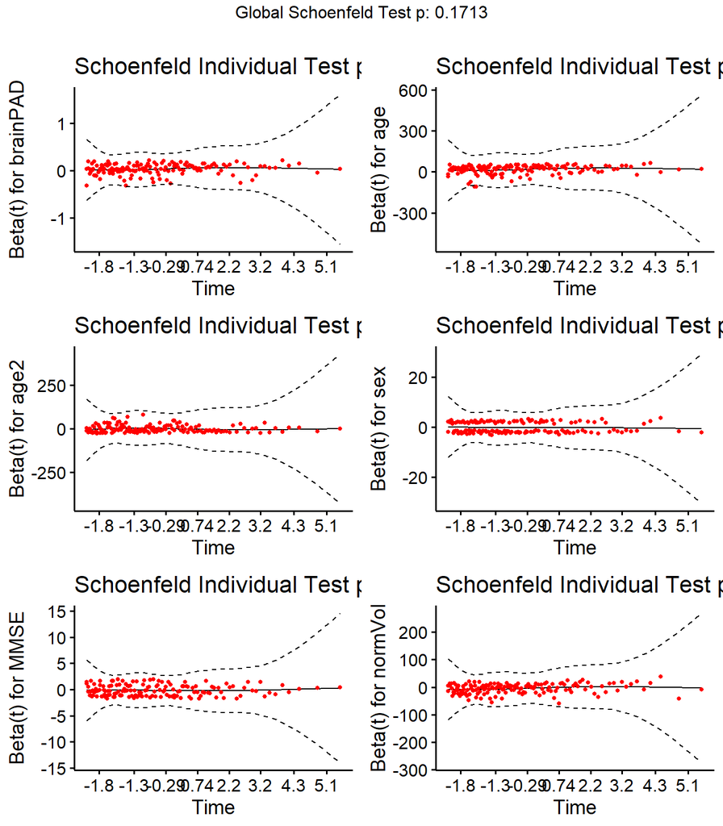

```r
#GLOBAL p>0.05 hence assumptions met

ggcoxzph(cox.zph(model_cox)) #correlations of DVs with time to ensure that assumptions of ph are met
```

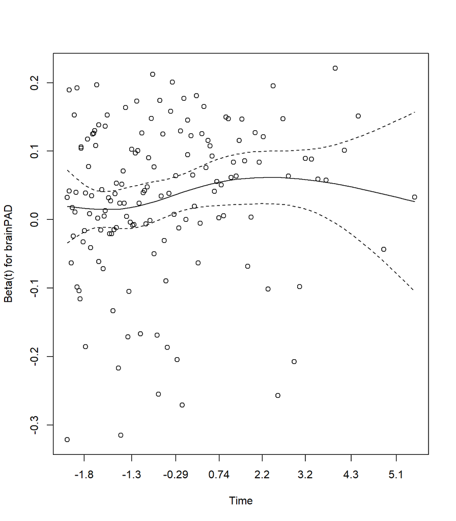

```r
plot(cox.zph(model_cox)[1]) #brainPAD only
```

### Table 2b Cox regression results

```r
# subversion list
#1) PolyT, CentT = TFT: data is centred, age and age2 polynomials include
#2) PolyT, CentZ = TTT: data is standardized, age and age2 polynomials included
#3) PolyT, CentF = FFT: data is raw, age and age2 polynomials included
#4) PolyF, CentT = TFF: data is centred,age2 and poly excluded
#5) PolyF, CentZ = TTF: data is standardized, age2 and poly excluded
#6) PolyF, CentF = FFF: data is raw, age2 and poly excluded

subversion <- c("TFT","TTT", "FFT","TFF","TTF","FFF")


#loop through subversion
for (i in seq_along(subversion)){
  v <- subversion[i]

  table2COX <- flogtablefun(datasub2,type='cox',Center=ftruefun(substring(v,1,1)),Scale=ftruefun(substring(v,2,2)),Poly=ftruefun(substring(v,3,3)))

  table2COX2 <- table2COX[[1]] #extract table

  # print to console
  tt <- kbl(table2COX2,caption=paste("Table",i," ",table2COX[[2]])) %>%
  kable_classic(full_width = T, html_font = "Cambria",position = "left")%>%
  print(tt)
  cat("\n\n")

  nr <- nrow(table2COX2)
  table2COX2[[nr+1,1]] <- paste("Caption: ",table2COX[[2]]) #add caption

  #save table to file for export
  write.xlsx(table2COX2, paste(outputpath,table2COX[[3]],sep=""), row.names=T, col.names=T) #save to xls

}
```

Table 1 (2b) Cox PH Regression Results, version = sensitivity2 with quadratic age (polynomial) Vars are centred

| rn | n/N | HR(CI) | p-value |
| --- | --- | --- | --- |
| age | 146/471 | 12188042.259590 (24700.014833-6014100603.798437) | <0.0001 |
| age2 | 146/471 | 0.477095 (0.003731-61.000562) | 0.7649 |
| sex | 146/471 | 0.825948 (0.589091-1.158038) | 0.2674 |
| brainPAD | 146/471 | 1.032150 (1.013787-1.050846) | 0.0006 |
| MMSE | 146/471 | 0.864442 (0.735093-1.016552) | 0.0782 |
| normVol | 146/471 | 0.005167 (0.000238-0.111995) | 0.0008 |

Table 2 (2b) Cox PH Regression Results, version = sensitivity2 with quadratic age (polynomial) Vars are standardized

| rn | n/N | HR(CI) | p-value |
| --- | --- | --- | --- |
| age | 146/471 | 2.122510 (1.594483-2.825397) | <0.0001 |
| age2 | 146/471 | 0.966441 (0.772679-1.208791) | 0.7649 |
| sex | 146/471 | 0.825948 (0.589091-1.158038) | 0.2674 |
| brainPAD | 146/471 | 1.362528 (1.143230-1.623892) | 0.0006 |
| MMSE | 146/471 | 0.853223 (0.715083-1.018049) | 0.0782 |
| normVol | 146/471 | 0.731982 (0.610014-0.878338) | 0.0008 |

Table 3 (2b) Cox PH Regression Results, version = sensitivity2 with quadratic age (polynomial) Vars are not-centred

| rn | n/N | HR(CI) | p-value |
| --- | --- | --- | --- |
| age | 146/471 | 12188042.259590 (24700.014833-6014100603.798459) | <0.0001 |
| age2 | 146/471 | 0.477095 (0.003731-61.000562) | 0.7649 |
| sex | 146/471 | 0.825948 (0.589091-1.158038) | 0.2674 |
| brainPAD | 146/471 | 1.032150 (1.013787-1.050846) | 0.0006 |
| MMSE | 146/471 | 0.864442 (0.735093-1.016552) | 0.0782 |
| normVol | 146/471 | 0.005167 (0.000238-0.111995) | 0.0008 |

Table 4 (2b) Cox PH Regression Results, version = sensitivity2 without quadratic age Vars are centred

| rn | n/N | HR(CI) | p-value |
| --- | --- | --- | --- |
| age | 146/471 | 1.068080 (1.045274-1.091384) | <0.0001 |
| sex | 146/471 | 0.829939 (0.592765-1.162009) | 0.2777 |
| brainPAD | 146/471 | 1.031895 (1.013694-1.050423) | 0.0005 |
| MMSE | 146/471 | 0.864793 (0.735300-1.017091) | 0.0792 |
| normVol | 146/471 | 0.005123 (0.000237-0.110657) | 0.0008 |

Table 5 (2b) Cox PH Regression Results, version = sensitivity2 without quadratic age Vars are standardized

| rn | n/N | HR(CI) | p-value |
| --- | --- | --- | --- |
| age | 146/471 | 2.076502 (1.634331-2.638303) | <0.0001 |
| sex | 146/471 | 0.829939 (0.592765-1.162009) | 0.2777 |
| brainPAD | 146/471 | 1.359236 (1.142203-1.617509) | 0.0005 |
| MMSE | 146/471 | 0.853601 (0.715302-1.018638) | 0.0792 |
| normVol | 146/471 | 0.731616 (0.609837-0.877713) | 0.0008 |

Table 6 (2b) Cox PH Regression Results, version = sensitivity2 without quadratic age Vars are not-centred

| rn | n/N | HR(CI) | p-value |
| --- | --- | --- | --- |
| age | 146/471 | 1.068080 (1.045274-1.091384) | <0.0001 |
| sex | 146/471 | 0.829939 (0.592765-1.162009) | 0.2777 |
| brainPAD | 146/471 | 1.031895 (1.013694-1.050423) | 0.0005 |
| MMSE | 146/471 | 0.864793 (0.735300-1.017091) | 0.0792 |
| normVol | 146/471 | 0.005123 (0.000237-0.110657) | 0.0008 |

### Figure 4: Kaplan-Meier plot

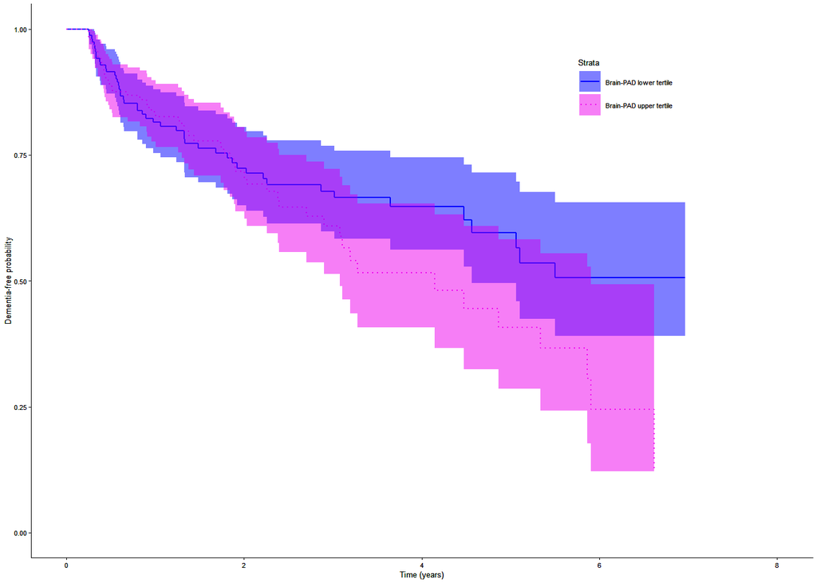

```r
## Prep data for Kaplan-Meir plot
dataKM <- datasub2 %>%
  dplyr::mutate(split_brainPAD = ntile(brainPAD, 3))%>% #create tertile groups
  .[.$split_brainPAD!=2,] #remove middle tertile

#extract response function from coxreg and get surviva fit object
KM_S <- fcoxregfun (dataKM,Center=F,Scale=F,Poly=T)[[2]] #for illustration no need to center
sv.object <- survfit(KM_S  ~ split_brainPAD, data = dataKM)

survplot <- ggsurvplot(sv.object,
                       ggtheme = theme_cowplot(font_size = 5, line_size = 0.2, rel_large = 1),
                       risk.table = F, risk.table.fontsize = 1.2,cumcensor = F, conf.int = T,
                       palette = c("blue1", "magenta2"),linetype = c(1,3),size = 0.5,
                       censor = F,xlab = "Time (years)",ylab = "Dementia-free probability",
                       legend = c(0.7,0.85),legend.labs = c("Brain-PAD lower tertile", "Brain-PAD upper tertile"))

survplot$plot <- survplot$plot + theme(legend.key.size = unit(1, "line")) + xlim(0,7)
survplot

filename <- paste(outputpath,"Fig4_KM_brain-PAD_",versionname,".tif",sep="")
ggsave(filename = filename, height = 50, width = 80, print(survplot, newpage = FALSE), device = "tiff", dpi = picres, units = "mm")
```

## Assessing multicollinearity

```r
#correlation matrix
temp_data <- datasub2%>%
    select(age, MMSE_numerator, brainPAD, normVol,End_scan2Endyears)
corrmatrix <- rcorr(as.matrix(temp_data))
corrmatrix
```

```
##                     age MMSE_numerator brainPAD normVol End_scan2Endyears
## age                1.00          -0.16    -0.27   -0.49             -0.08
## MMSE_numerator    -0.16           1.00     0.11    0.13              0.09
## brainPAD          -0.27           0.11     1.00    0.02             -0.10
## normVol           -0.49           0.13     0.02    1.00              0.07
## End_scan2Endyears -0.08           0.09    -0.10    0.07              1.00
##
## n= 471
##
##
## P
##                   age    MMSE_numerator brainPAD normVol End_scan2Endyears
## age                      0.0004         0.0000   0.0000  0.0802
## MMSE_numerator    0.0004                0.0193   0.0038  0.0498
## brainPAD          0.0000 0.0193                  0.6931  0.0320
## normVol           0.0000 0.0038         0.6931           0.1578
## End_scan2Endyears 0.0802 0.0498         0.0320   0.1578
```

```r
df.corrmatrix.r=data.frame(corrmatrix$r)
df.corrmatrix.p=data.frame(corrmatrix$P)
filename1 <- paste(outputpath,"correlationmatrix_r_",versionname,".xlsx",sep="")
filename2 <- paste(outputpath,"correlationmatrix_p_",versionname,".xlsx",sep="")
write.xlsx(df.corrmatrix.r,filename1, rowNames=T, colNames=T)
write.xlsx(df.corrmatrix.p,filename2, rowNames=T, colNames=T)


#VIF  - variance inflation factor
car::vif(model_log) #extract VIFs based on logistic regression model
```

```
##      age     age2      sex brainPAD  normVol     MMSE
## 1.875374 1.671299 1.071822 1.144958 1.161498 1.025744
```